# Classifying bullying, parental substance use, parental mental illness, & not living with both parents in BiB Birth Cohort

## Outcome dr24 distribution

https://www.youtube.com/watch?v=cPL7I7Vyt9I

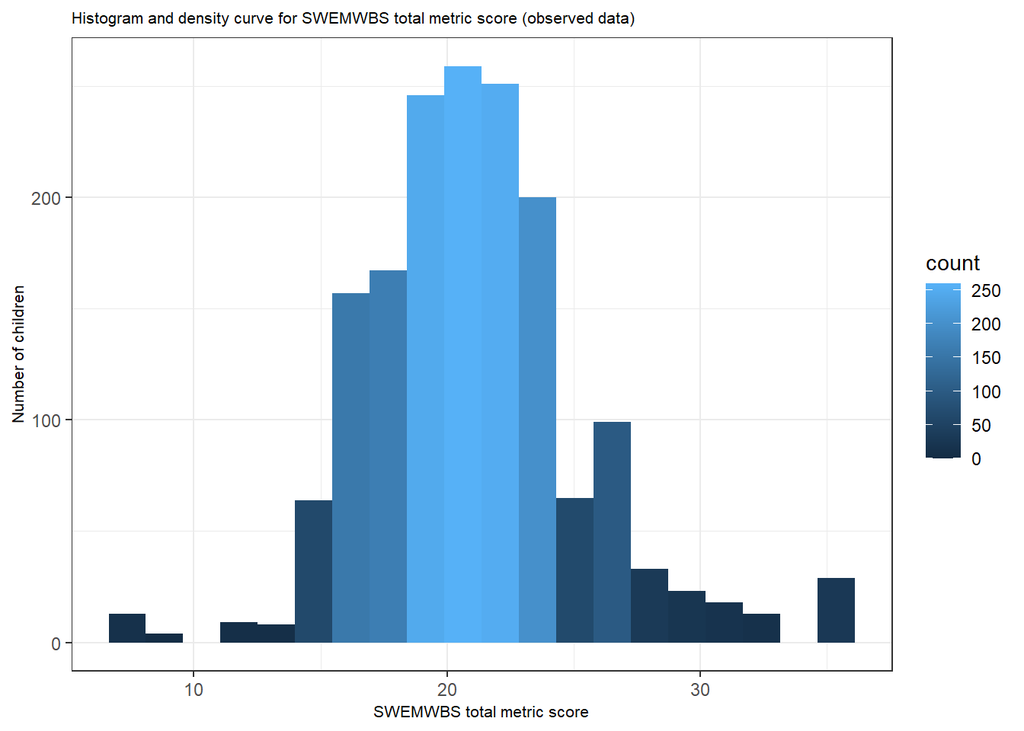

```r
# SWEMWBS
df2662_complcase %>%
    ggplot(aes(x = swemwbs_sum_scaled)) + geom_histogram(aes(y = after_stat(count),
    fill = after_stat(count)), bins = 20) + theme_bw() + theme(plot.title = element_text(size = 8),
    axis.title.x = element_text(size = 8), axis.title.y = element_text(size = 8)) +
    labs(title = "Histogram and density curve for SWEMWBS total metric score (observed data)",
        x = "SWEMWBS total metric score", y = "Number of children")
```

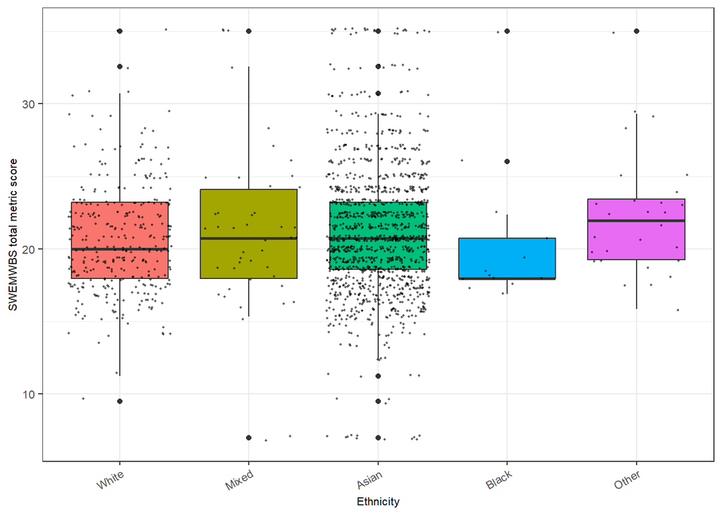

```r
# SWEMWBS by ethnicity
df2662_complcase %>%
    ggplot(aes(x = ethnicity5_C_T1, y = swemwbs_sum_scaled, fill = factor(ethnicity5_C_T1))) +
    geom_boxplot() + geom_jitter(color = "black", size = 0.3, alpha = 0.5) + theme_bw() +
    theme(axis.title.y = element_text(size = 8), axis.title.x = element_text(size = 8)) +
    labs(y = "SWEMWBS total metric score", x = "Ethnicity") + guides(fill = "none",
    color = "none") + theme(axis.text.x = element_text(angle = 30, vjust = 1, hjust = 1),
    text = element_text(size = 10))
```

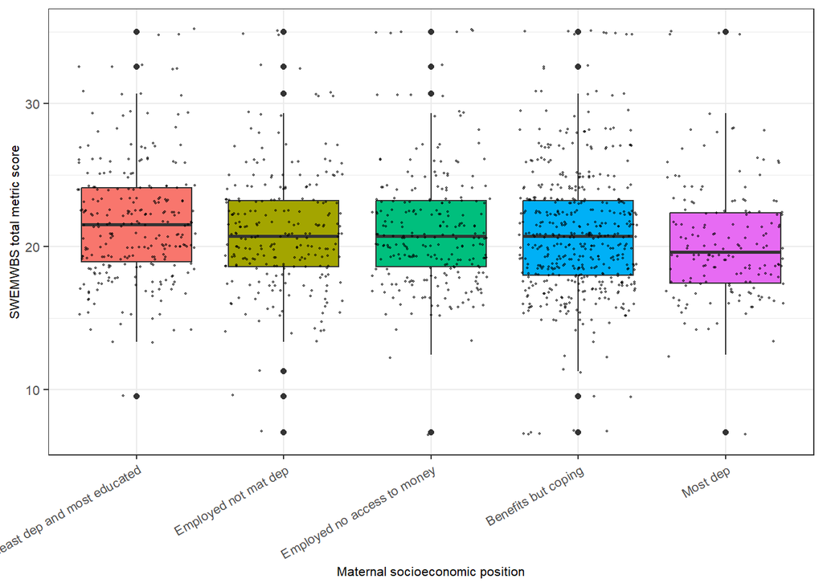

```r
# SWEMWBS by SEP
df2662_complcase %>%
    drop_na(mbqlcasep5gp_T0) %>%
    ggplot(aes(x = mbqlcasep5gp_T0, y = swemwbs_sum_scaled, fill = factor(mbqlcasep5gp_T0))) +
    geom_boxplot() + geom_jitter(color = "black", size = 0.3, alpha = 0.5) + theme_bw() +
    theme(axis.title.y = element_text(size = 8), axis.title.x = element_text(size = 8)) +
    labs(y = "SWEMWBS total metric score", x = "Maternal socioeconomic position") +
    guides(fill = "none", color = "none") + theme(axis.text.x = element_text(angle = 30,
    vjust = 1, hjust = 1), text = element_text(size = 10))
```

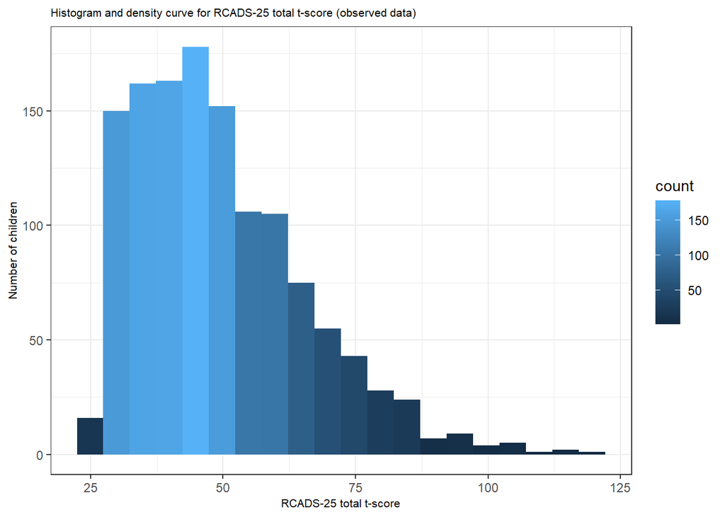

```r
# RCADS-25 total t-score
df2662_complcase %>%
    ggplot(aes(x = rcad_total_t)) + geom_histogram(aes(y = after_stat(count), fill = after_stat(count)),
    bins = 20) + theme_bw() + theme(plot.title = element_text(size = 8), axis.title.x = element_text(size = 8),
    axis.title.y = element_text(size = 8)) + labs(title = "Histogram and density curve for RCADS-25 total t-score (observed data)",
    x = "RCADS-25 total t-score", y = "Number of children")
```

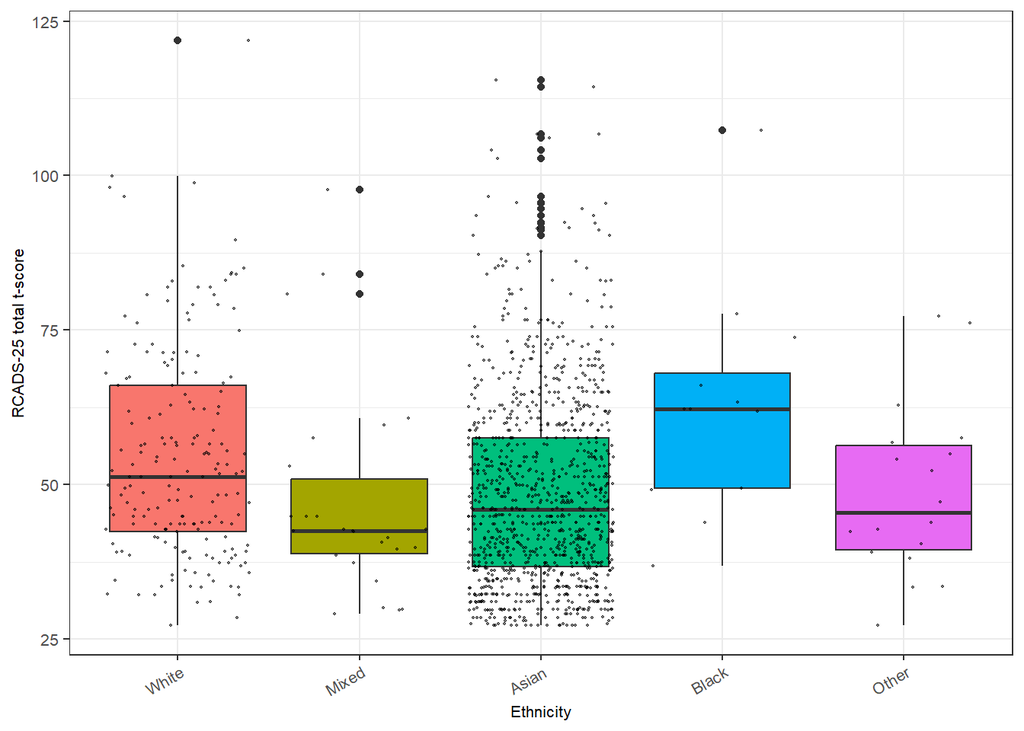

```r
# RCADS-25 by ethnicity
df2662_complcase %>%
    ggplot(aes(x = ethnicity5_C_T1, y = rcad_total_t, fill = factor(ethnicity5_C_T1))) +
    geom_boxplot() + geom_jitter(color = "black", size = 0.3, alpha = 0.5) + theme_bw() +
    theme(axis.title.y = element_text(size = 8), axis.title.x = element_text(size = 8)) +
    labs(y = "RCADS-25 total t-score", x = "Ethnicity") + guides(fill = "none", color = "none") +
    theme(axis.text.x = element_text(angle = 30, vjust = 1, hjust = 1), text = element_text(size = 10))
```

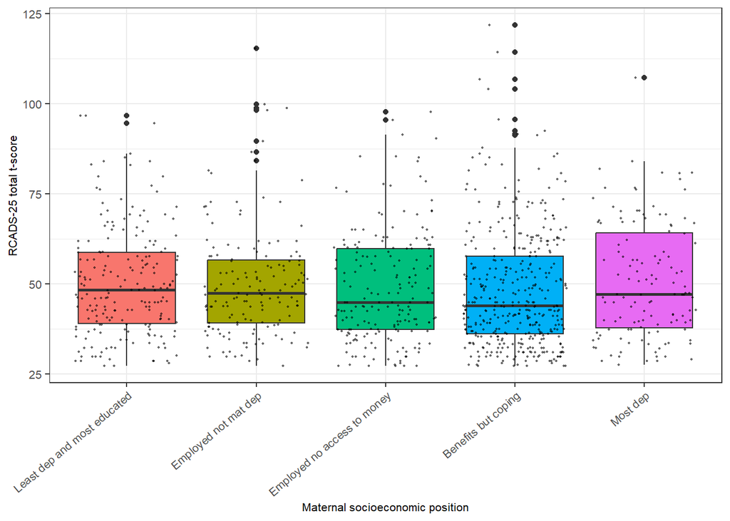

```r
# RCADS-25 by SEP
df2662_complcase %>%
    drop_na(mbqlcasep5gp_T0) %>%
    ggplot(aes(x = mbqlcasep5gp_T0, y = rcad_total_t, fill = factor(mbqlcasep5gp_T0))) +
    geom_boxplot() + geom_jitter(color = "black", size = 0.3, alpha = 0.5) + theme_bw() +
    theme(axis.title.y = element_text(size = 8), axis.title.x = element_text(size = 8)) +
    labs(y = "RCADS-25 total t-score", x = "Maternal socioeconomic position") + guides(fill = "none",
    color = "none") + theme(axis.text.x = element_text(angle = 40, vjust = 1, hjust = 1),
    text = element_text(size = 10))
```

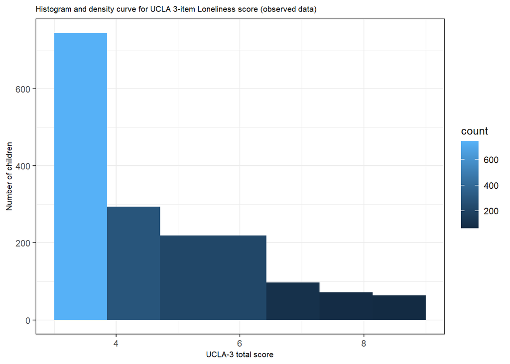

```r
# UCLA-3 total score
df2662_complcase %>%
    ggplot(aes(x = loneliness_sum)) + geom_histogram(aes(y = after_stat(count), fill = after_stat(count)),
    bins = 8) + theme_bw() + theme(plot.title = element_text(size = 8), axis.title.x = element_text(size = 8),
    axis.title.y = element_text(size = 8)) + labs(title = "Histogram and density curve for UCLA 3-item Loneliness score (observed data)",
    x = "UCLA-3 total score", y = "Number of children")
```

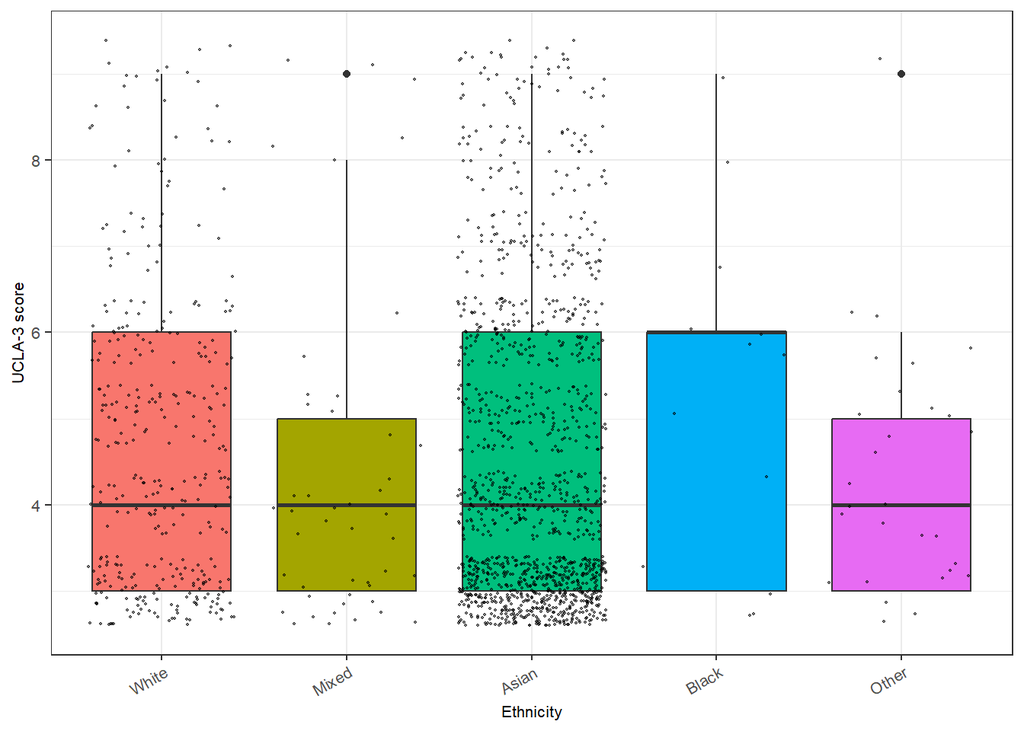

```r
# UCLA-3 by ethnicity
df2662_complcase %>%
    ggplot(aes(x = ethnicity5_C_T1, y = loneliness_sum, fill = factor(ethnicity5_C_T1))) +
    geom_boxplot() + geom_jitter(color = "black", size = 0.3, alpha = 0.5) + theme_bw() +
    theme(axis.title.y = element_text(size = 8), axis.title.x = element_text(size = 8)) +
    labs(y = "UCLA-3 score", x = "Ethnicity") + guides(fill = "none", color = "none") +
    theme(axis.text.x = element_text(angle = 30, vjust = 1, hjust = 1), text = element_text(size = 10))
```

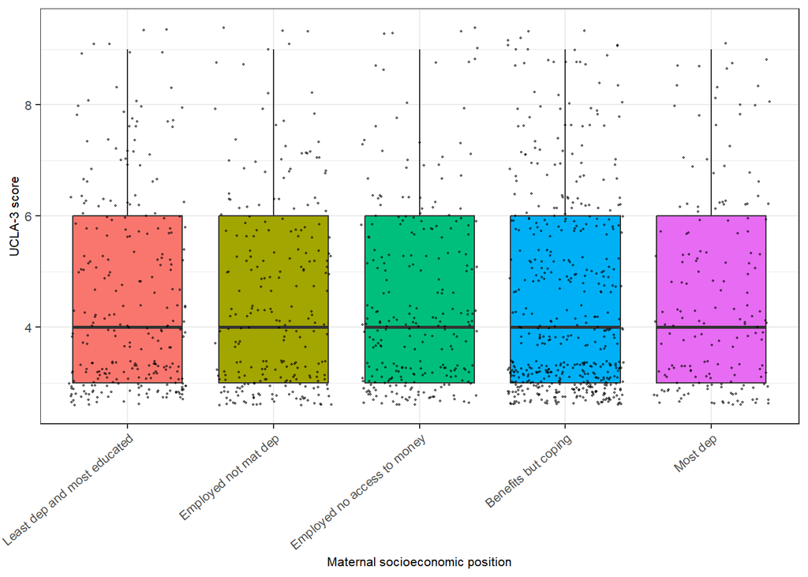

```r
# UCLA-3 by SEP
df2662_complcase %>%
    drop_na(mbqlcasep5gp_T0) %>%
    ggplot(aes(x = mbqlcasep5gp_T0, y = loneliness_sum, fill = factor(mbqlcasep5gp_T0))) +
    geom_boxplot() + geom_jitter(color = "black", size = 0.3, alpha = 0.5) + theme_bw() +
    theme(axis.title.y = element_text(size = 8), axis.title.x = element_text(size = 8)) +
    labs(y = "UCLA-3 score", x = "Maternal socioeconomic position") + guides(fill = "none",
    color = "none") + theme(axis.text.x = element_text(angle = 40, vjust = 1, hjust = 1),
    text = element_text(size = 10))
```

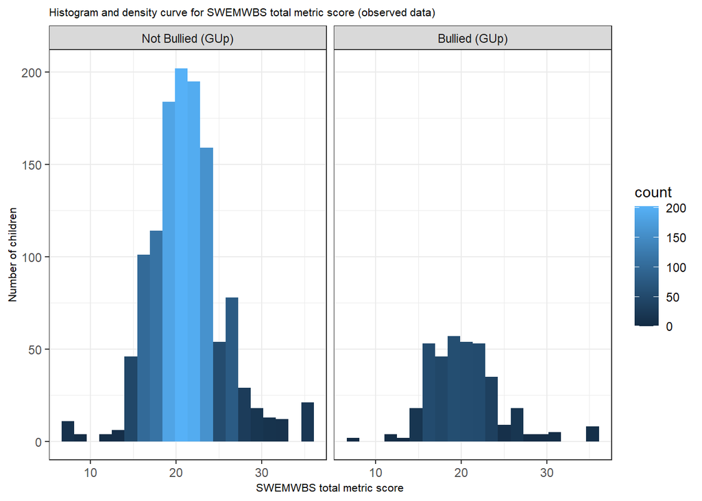

```r
# Exploring the conditional distribution of each AE on each continuous/integer outcome - only use complete case in report

# each AE on SWEMWBS t-score ggplot (conditional distribution)
df2662_complcase %>% drop_na(GU_bullied_T1) %>%
  ggplot(aes(x=swemwbs_sum_scaled))+
  geom_histogram(aes(y=after_stat(count), fill=after_stat(count)), bins=20)+
  theme_bw() +
  theme(plot.title = element_text(size = 8),
        axis.title.x = element_text(size = 8),
        axis.title.y = element_text(size = 8)) +
  labs(title="Histogram and density curve for SWEMWBS total metric score (observed data)",
       x="SWEMWBS total metric score",
       y="Number of children") +
  facet_wrap(~ GU_bullied_T1)
```

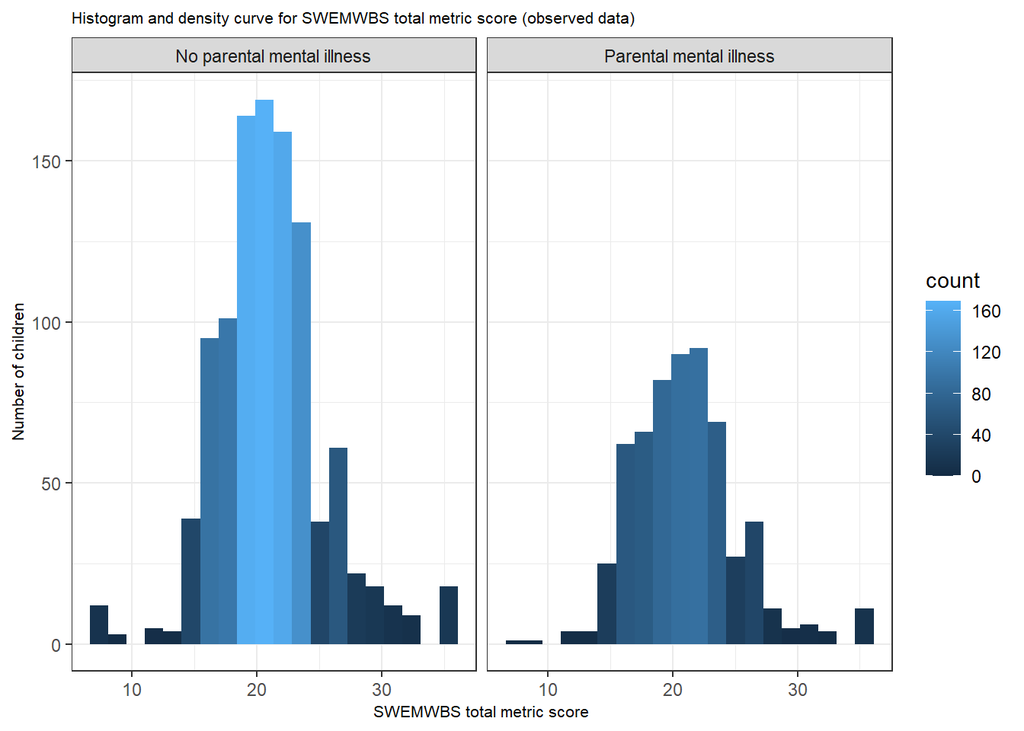

```r
df2662_complcase %>% drop_na(anyMIT0_T1) %>%
  ggplot(aes(x=swemwbs_sum_scaled))+
  geom_histogram(aes(y=after_stat(count), fill=after_stat(count)), bins=20)+
  theme_bw() +
  theme(plot.title = element_text(size = 8),
        axis.title.x = element_text(size = 8),
        axis.title.y = element_text(size = 8)) +
  labs(title="Histogram and density curve for SWEMWBS total metric score (observed data)",
       x="SWEMWBS total metric score",
       y="Number of children") +
  facet_wrap(~ anyMIT0_T1)
```

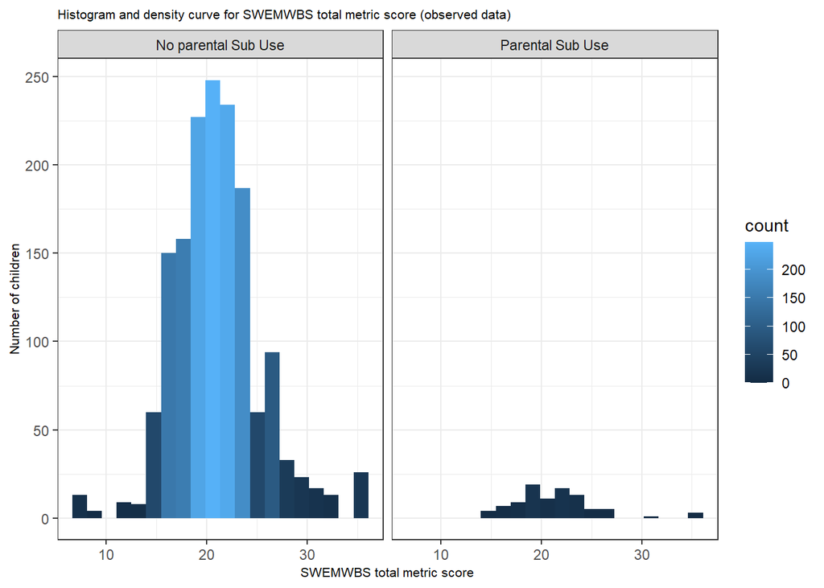

```r
df2662_complcase %>% drop_na(anyAlcSubProbT0_T1) %>%
  ggplot(aes(x=swemwbs_sum_scaled))+
  geom_histogram(aes(y=after_stat(count), fill=after_stat(count)), bins=20)+
  theme_bw() +
  theme(plot.title = element_text(size = 8),
        axis.title.x = element_text(size = 8),
        axis.title.y = element_text(size = 8)) +
  labs(title="Histogram and density curve for SWEMWBS total metric score (observed data)",
       x="SWEMWBS total metric score",
       y="Number of children") +
  facet_wrap(~ anyAlcSubProbT0_T1)
```

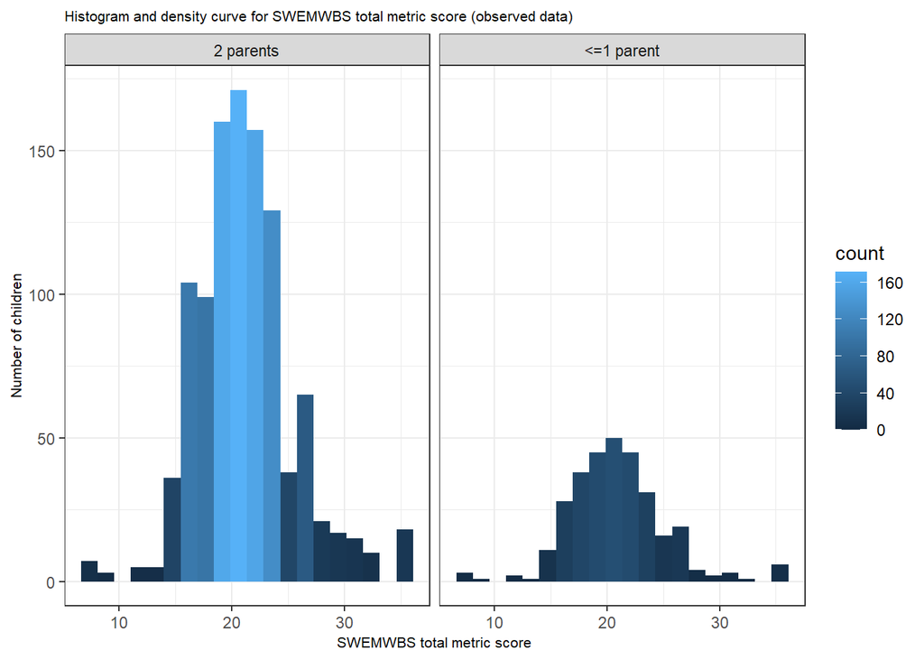

```r
df2662_complcase %>% drop_na(anyNotlivewithMFT0_T1) %>%
  ggplot(aes(x=swemwbs_sum_scaled))+
  geom_histogram(aes(y=after_stat(count), fill=after_stat(count)), bins=20)+
  theme_bw() +
  theme(plot.title = element_text(size = 8),
        axis.title.x = element_text(size = 8),
        axis.title.y = element_text(size = 8)) +
  labs(title="Histogram and density curve for SWEMWBS total metric score (observed data)",
       x="SWEMWBS total metric score",
       y="Number of children") +
  facet_wrap(~ anyNotlivewithMFT0_T1)
```

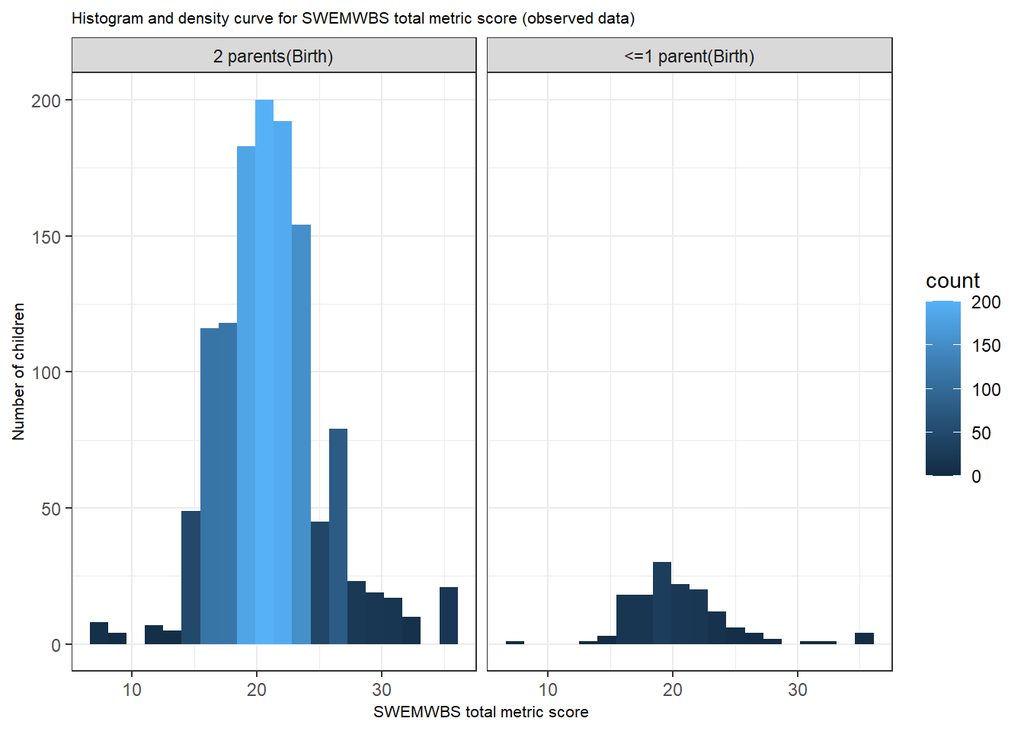

```r
df2662_complcase %>% drop_na(notlivewithMF_base_T0) %>%
  ggplot(aes(x=swemwbs_sum_scaled))+
  geom_histogram(aes(y=after_stat(count), fill=after_stat(count)), bins=20)+
  theme_bw() +
  theme(plot.title = element_text(size = 8),
        axis.title.x = element_text(size = 8),
        axis.title.y = element_text(size = 8)) +
  labs(title="Histogram and density curve for SWEMWBS total metric score (observed data)",
       x="SWEMWBS total metric score",
       y="Number of children") +
  facet_wrap(~ notlivewithMF_base_T0)
```

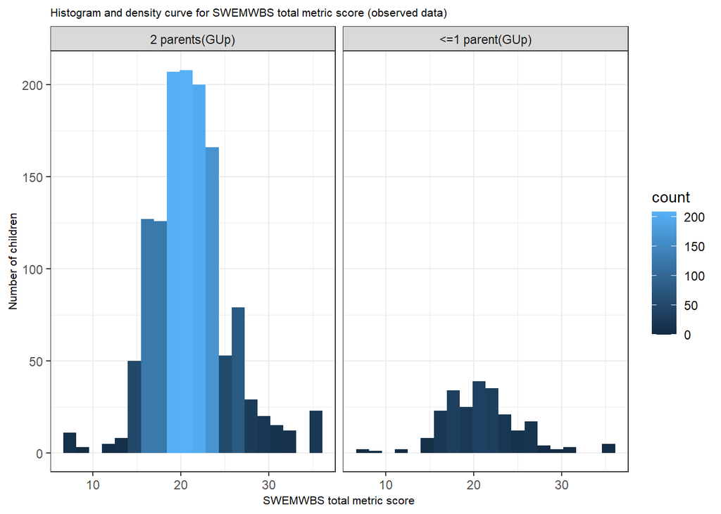

```r
df2662_complcase %>% drop_na(notlivewithMF_gu_T1) %>%
  ggplot(aes(x=swemwbs_sum_scaled))+
  geom_histogram(aes(y=after_stat(count), fill=after_stat(count)), bins=20)+
  theme_bw() +
  theme(plot.title = element_text(size = 8),
        axis.title.x = element_text(size = 8),
        axis.title.y = element_text(size = 8)) +
  labs(title="Histogram and density curve for SWEMWBS total metric score (observed data)",
       x="SWEMWBS total metric score",
       y="Number of children") +
  facet_wrap(~ notlivewithMF_gu_T1)
```

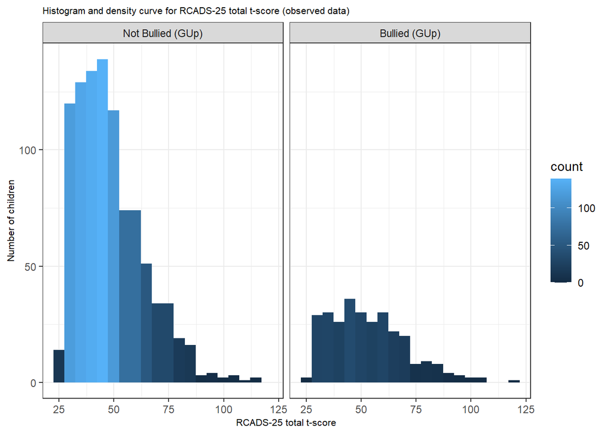

```r
# each AE on RCADS-25 ggplot (conditional distribution)

df2662_complcase %>% drop_na(GU_bullied_T1) %>%
  ggplot(aes(x=rcad_total_t))+
  geom_histogram(aes(y=after_stat(count), fill=after_stat(count)), bins=20)+
  theme_bw() +
  theme(plot.title = element_text(size = 8),
        axis.title.x = element_text(size = 8),
        axis.title.y = element_text(size = 8)) +
  labs(title="Histogram and density curve for RCADS-25 total t-score (observed data)",
       x="RCADS-25 total t-score",
       y="Number of children") +
  facet_wrap(~ GU_bullied_T1)
```

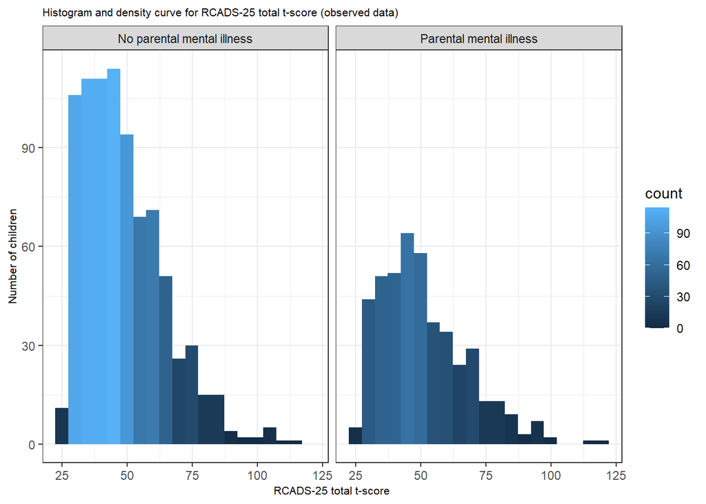

```r
df2662_complcase %>% drop_na(anyMIT0_T1) %>%
  ggplot(aes(x=rcad_total_t))+
  geom_histogram(aes(y=after_stat(count), fill=after_stat(count)), bins=20)+
  theme_bw() +
  theme(plot.title = element_text(size = 8),
        axis.title.x = element_text(size = 8),
        axis.title.y = element_text(size = 8)) +
  labs(title="Histogram and density curve for RCADS-25 total t-score (observed data)",
       x="RCADS-25 total t-score",
       y="Number of children") +
  facet_wrap(~ anyMIT0_T1)
```

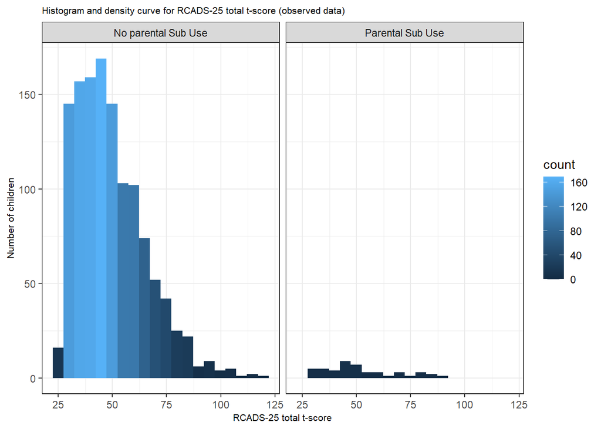

```r
df2662_complcase %>% drop_na(anyAlcSubProbT0_T1) %>%
  ggplot(aes(x=rcad_total_t))+
  geom_histogram(aes(y=after_stat(count), fill=after_stat(count)), bins=20)+
  theme_bw() +
  theme(plot.title = element_text(size = 8),
        axis.title.x = element_text(size = 8),
        axis.title.y = element_text(size = 8)) +
  labs(title="Histogram and density curve for RCADS-25 total t-score (observed data)",
       x="RCADS-25 total t-score",
       y="Number of children") +
  facet_wrap(~ anyAlcSubProbT0_T1)
```

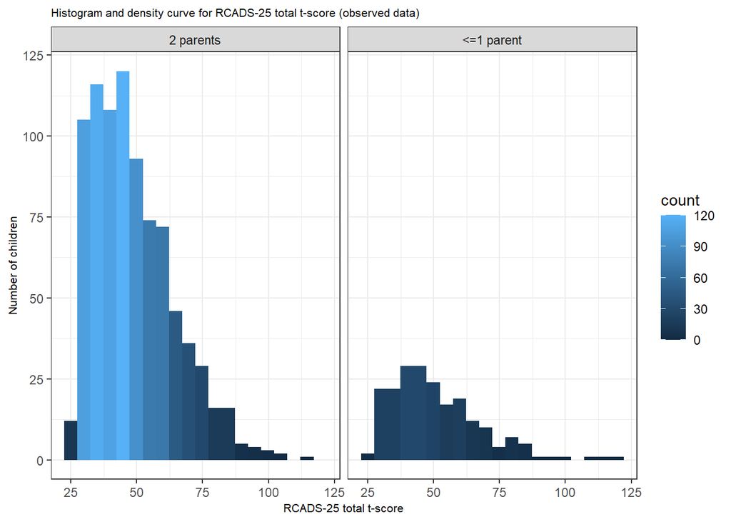

```r
df2662_complcase %>% drop_na(anyNotlivewithMFT0_T1) %>%
  ggplot(aes(x=rcad_total_t))+
  geom_histogram(aes(y=after_stat(count), fill=after_stat(count)), bins=20)+
  theme_bw() +
  theme(plot.title = element_text(size = 8),
        axis.title.x = element_text(size = 8),
        axis.title.y = element_text(size = 8)) +
  labs(title="Histogram and density curve for RCADS-25 total t-score (observed data)",
       x="RCADS-25 total t-score",
       y="Number of children") +
  facet_wrap(~ anyNotlivewithMFT0_T1)
```

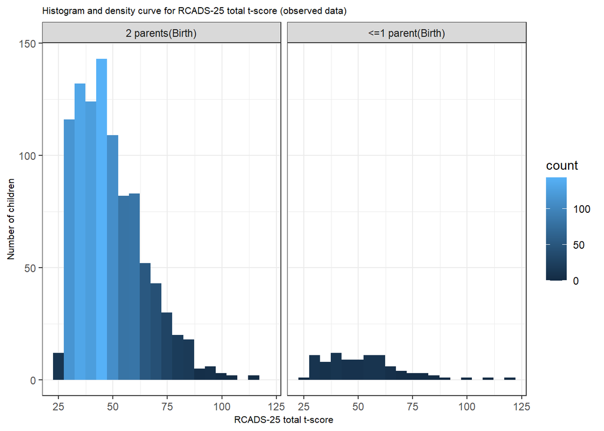

```r
df2662_complcase %>% drop_na(notlivewithMF_base_T0) %>%
  ggplot(aes(x=rcad_total_t))+
  geom_histogram(aes(y=after_stat(count), fill=after_stat(count)), bins=20)+
  theme_bw() +
  theme(plot.title = element_text(size = 8),
        axis.title.x = element_text(size = 8),
        axis.title.y = element_text(size = 8)) +
  labs(title="Histogram and density curve for RCADS-25 total t-score (observed data)",
       x="RCADS-25 total t-score",
       y="Number of children") +
  facet_wrap(~ notlivewithMF_base_T0)
```

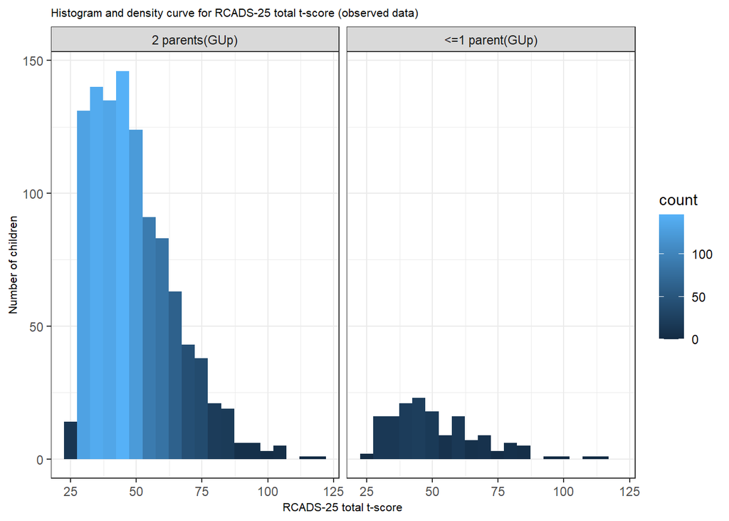

```r
df2662_complcase %>% drop_na(notlivewithMF_gu_T1) %>%
  ggplot(aes(x=rcad_total_t))+
  geom_histogram(aes(y=after_stat(count), fill=after_stat(count)), bins=20)+
  theme_bw() +
  theme(plot.title = element_text(size = 8),
        axis.title.x = element_text(size = 8),
        axis.title.y = element_text(size = 8)) +
  labs(title="Histogram and density curve for RCADS-25 total t-score (observed data)",
       x="RCADS-25 total t-score",
       y="Number of children") +
  facet_wrap(~ notlivewithMF_gu_T1)
```

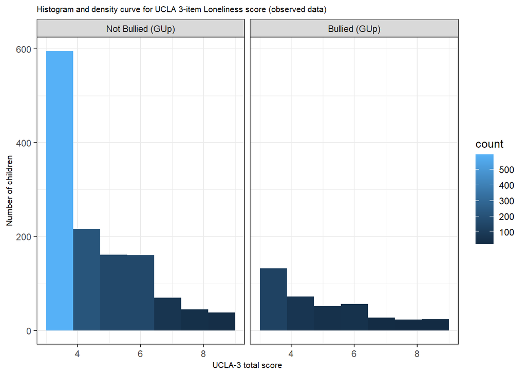

```r
# each AE on UCLA-3 ggplot (conditional distribution)
df2662_complcase %>% drop_na(GU_bullied_T1) %>%
  ggplot(aes(x=loneliness_sum))+
  geom_histogram(aes(y=after_stat(count), fill=after_stat(count)), bins=8)+
  theme_bw() +
  theme(plot.title = element_text(size = 8),
        axis.title.x = element_text(size = 8),
        axis.title.y = element_text(size = 8)) +
  labs(title="Histogram and density curve for UCLA 3-item Loneliness score (observed data)",
       x="UCLA-3 total score",
       y="Number of children") +
  facet_wrap(~ GU_bullied_T1)
```

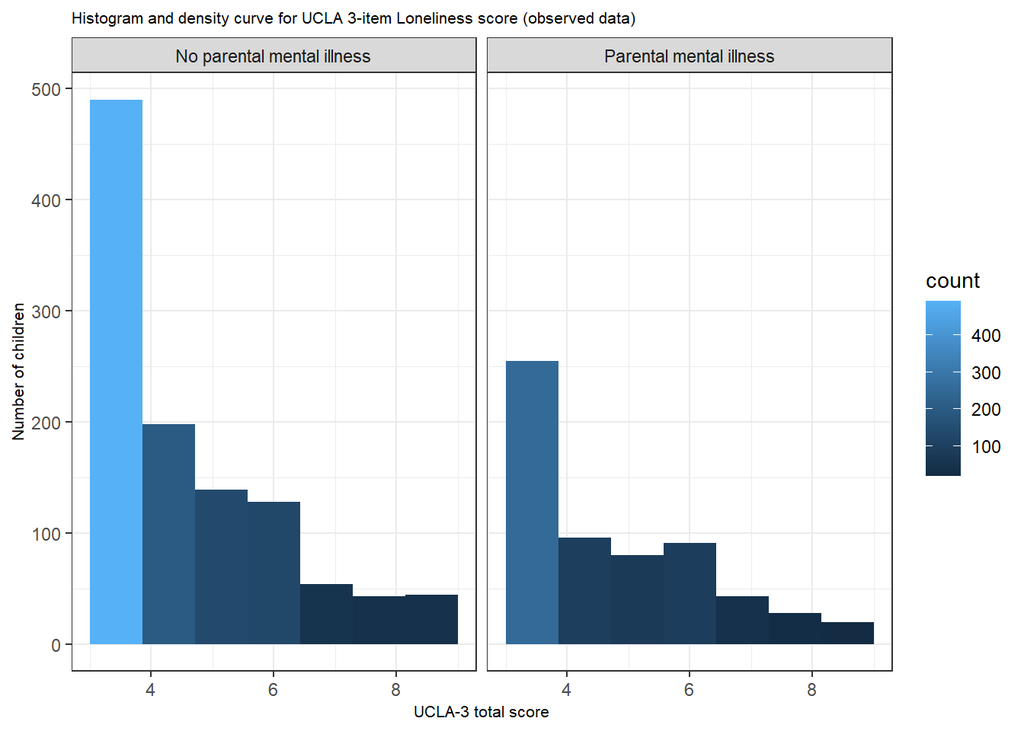

```r
df2662_complcase %>% drop_na(anyMIT0_T1) %>%
  ggplot(aes(x=loneliness_sum))+
  geom_histogram(aes(y=after_stat(count), fill=after_stat(count)), bins=8)+
  theme_bw() +
  theme(plot.title = element_text(size = 8),
        axis.title.x = element_text(size = 8),
        axis.title.y = element_text(size = 8)) +
  labs(title="Histogram and density curve for UCLA 3-item Loneliness score (observed data)",
       x="UCLA-3 total score",
       y="Number of children") +
  facet_wrap(~ anyMIT0_T1)
```

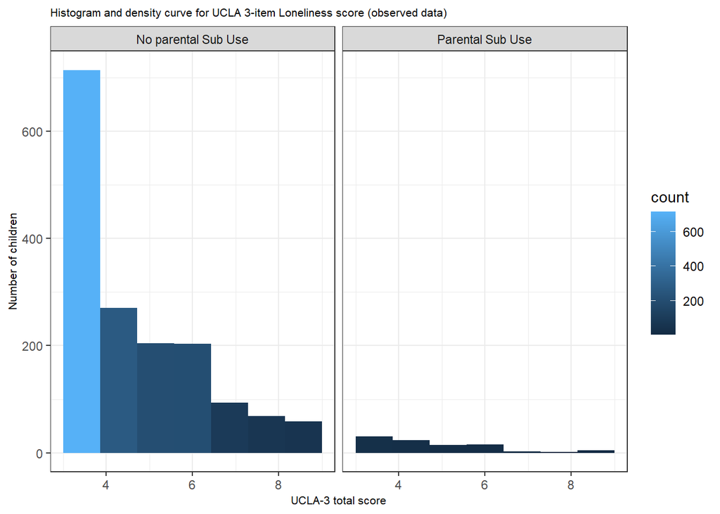

```r
df2662_complcase %>% drop_na(anyAlcSubProbT0_T1) %>%
  ggplot(aes(x=loneliness_sum))+
  geom_histogram(aes(y=after_stat(count), fill=after_stat(count)), bins=8)+
  theme_bw() +
  theme(plot.title = element_text(size = 8),
        axis.title.x = element_text(size = 8),
        axis.title.y = element_text(size = 8)) +
  labs(title="Histogram and density curve for UCLA 3-item Loneliness score (observed data)",
       x="UCLA-3 total score",
       y="Number of children") +
  facet_wrap(~ anyAlcSubProbT0_T1)
```

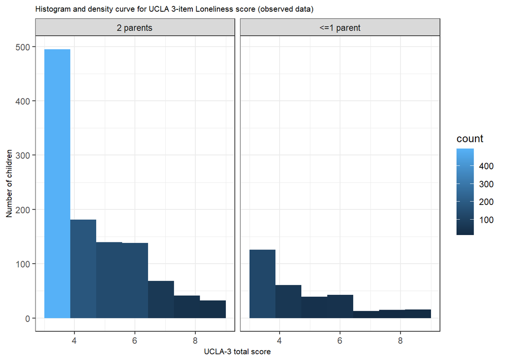

```r
df2662_complcase %>% drop_na(anyNotlivewithMFT0_T1) %>%
  ggplot(aes(x=loneliness_sum))+
  geom_histogram(aes(y=after_stat(count), fill=after_stat(count)), bins=8)+
  theme_bw() +
  theme(plot.title = element_text(size = 8),
        axis.title.x = element_text(size = 8),
        axis.title.y = element_text(size = 8)) +
  labs(title="Histogram and density curve for UCLA 3-item Loneliness score (observed data)",
       x="UCLA-3 total score",
       y="Number of children") +
  facet_wrap(~ anyNotlivewithMFT0_T1)
```

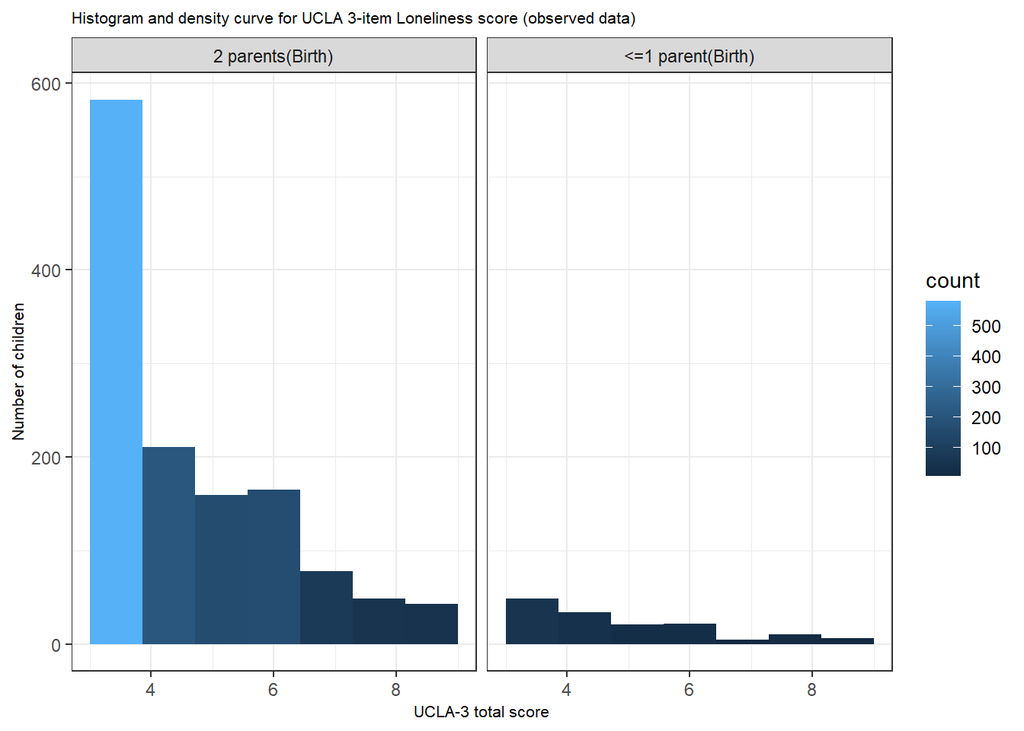

```r
df2662_complcase %>% drop_na(notlivewithMF_base_T0) %>%
  ggplot(aes(x=loneliness_sum))+
  geom_histogram(aes(y=after_stat(count), fill=after_stat(count)), bins=8)+
  theme_bw() +
  theme(plot.title = element_text(size = 8),
        axis.title.x = element_text(size = 8),
        axis.title.y = element_text(size = 8)) +
  labs(title="Histogram and density curve for UCLA 3-item Loneliness score (observed data)",
       x="UCLA-3 total score",
       y="Number of children") +
  facet_wrap(~ notlivewithMF_base_T0)
```

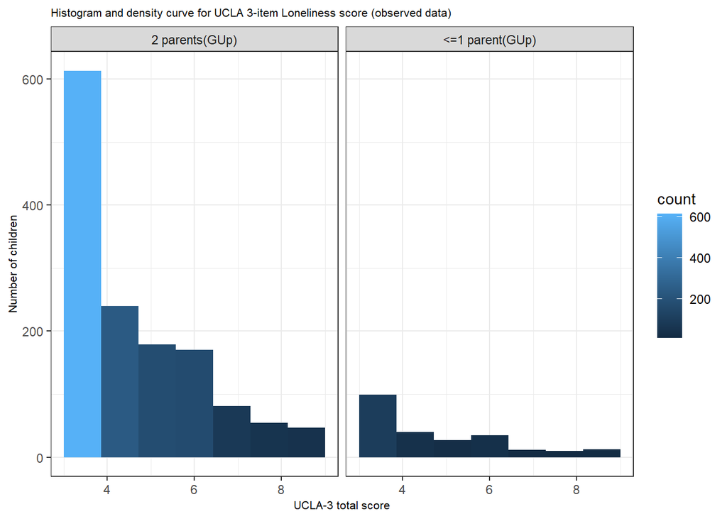

```r
df2662_complcase %>% drop_na(notlivewithMF_gu_T1) %>%
  ggplot(aes(x=loneliness_sum))+
  geom_histogram(aes(y=after_stat(count), fill=after_stat(count)), bins=8)+
  theme_bw() +
  theme(plot.title = element_text(size = 8),
        axis.title.x = element_text(size = 8),
        axis.title.y = element_text(size = 8)) +
  labs(title="Histogram and density curve for UCLA 3-item Loneliness score (observed data)",
       x="UCLA-3 total score",
       y="Number of children") +
  facet_wrap(~ notlivewithMF_gu_T1)
```

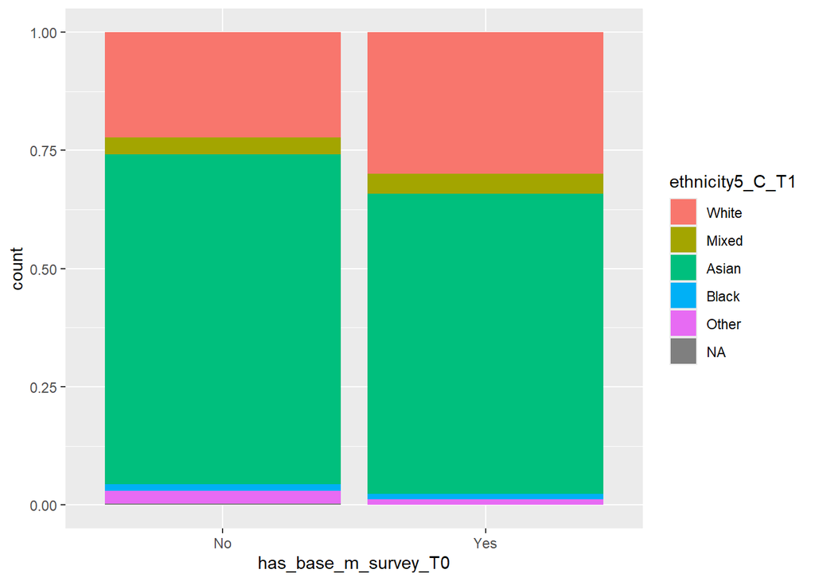

```r
ggplot(dr24, aes(x = has_base_m_survey_T0, fill = ethnicity5_C_T1)) + ## ethnicity5_C_T1 NA=5
  geom_bar(position = "fill")
```

```r
## The graph shows higher proportions of Asian, other, and NA ethnicity of the children whose mothers did not complete baseline mother survey.
```

The graphs show that age did not seem to be related to missing baseline mother survey. However, there were higher proportions of Asian, other, and NA ethnicity of the children whose mothers did not complete baseline mother survey.

## Sample characteristics

Notes regarding IMD, use the IMD_2010_score_T0 but not IMD_2019_score_T2, because there seems some systematic different between the values that for the same sample (n=2662), the values of IMP 2019 shifted to a lower range and the median was around 1.7 score lower with the imputed data.

Compare sample (BiB-C+GUp+AoW only) with baseline and GUp characteristics, e.g., who were the parents who participated in GUp and let their children be in AoW according to baseline (or may be GUp data too)?

```r
tableby.control <- tableby.control(
  test = TRUE,
  total = TRUE,
  total.pos = c("after", "before"),
  test.pname = NULL,
  numeric.simplify = FALSE,
  cat.simplify = FALSE,
  cat.droplevels = FALSE,
  ordered.simplify = FALSE,
  date.simplify = FALSE,
  numeric.test = "anova",
  cat.test = "chisq",
  ordered.test = "trend",
  surv.test = "logrank",
  date.test = "kwt",
  selectall.test = "notest",
  test.always = FALSE,
  numeric.stats = c("Nmiss", "meansd", "range"),
  cat.stats = c("Nmiss", "countpct"),
  ordered.stats = c("Nmiss", "countpct"),
  surv.stats = c("Nmiss", "Nevents", "medSurv"),
  date.stats = c("Nmiss", "median", "range"),
  selectall.stats = c("Nmiss", "countpct"),
  stats.labels = list(),
  digits = 3L,
  digits.count = 0L,
  digits.pct = 1L,
  digits.p = 3L,
  format.p = TRUE,
  digits.n = 0L,
  conf.level = 0.95,
  wilcox.correct = FALSE,
  wilcox.exact = NULL,
  chisq.correct = FALSE)
```

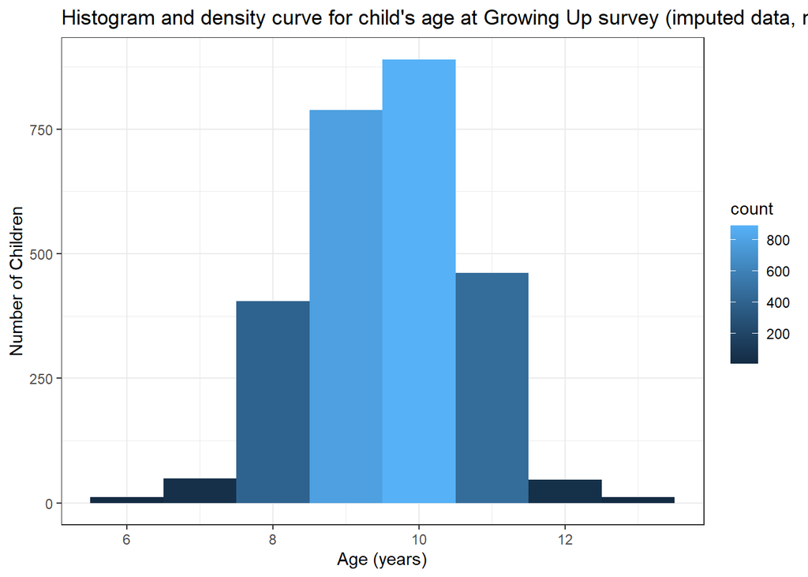

```r
# Child's age at GUp
df2662_complcase %>%
    ggplot(aes(x = GU_AgeYears_T1_derived)) + geom_histogram(aes(y = after_stat(count),
    fill = after_stat(count)), bins = 8) + theme_bw() + theme(plot.title = element_text(size = 8),
    axis.title.x = element_text(size = 8), axis.title.y = element_text(size = 8)) +
    labs(title = "Histogram and density curve for child's age at Growing Up survey (imputed data, n=2662)",
        x = "Age (years)", y = "Number of Children") + theme_bw()
```

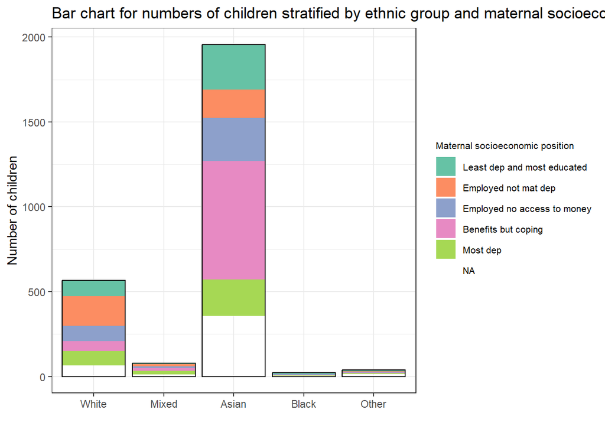

```r
# Ethnicity
df2662_complcase %>%
    ggplot(aes(x = as.factor(ethnicity5_C_T1), fill = ethnicity5_C_T1)) + geom_bar(aes(fill = factor(mbqlcasep5gp_T0))) +
    geom_bar(fill = NA, colour = "black") + scale_fill_brewer(palette = "Set2") +
    theme(plot.title = element_text(size = 8), axis.title.x = element_text(size = 8),
        axis.title.y = element_text(size = 8)) + labs(title = "Bar chart for numbers of children stratified by ethnic group and maternal socioeconomic position (n=2662)",
    x = "", y = "Number of children") + guides(fill = guide_legend(title = "Maternal socioeconomic position",
    theme(legend.title.position = "top", legend.title = element_text(size = 8), legend.text = element_text(size = 8)))) +
    theme_bw()
```

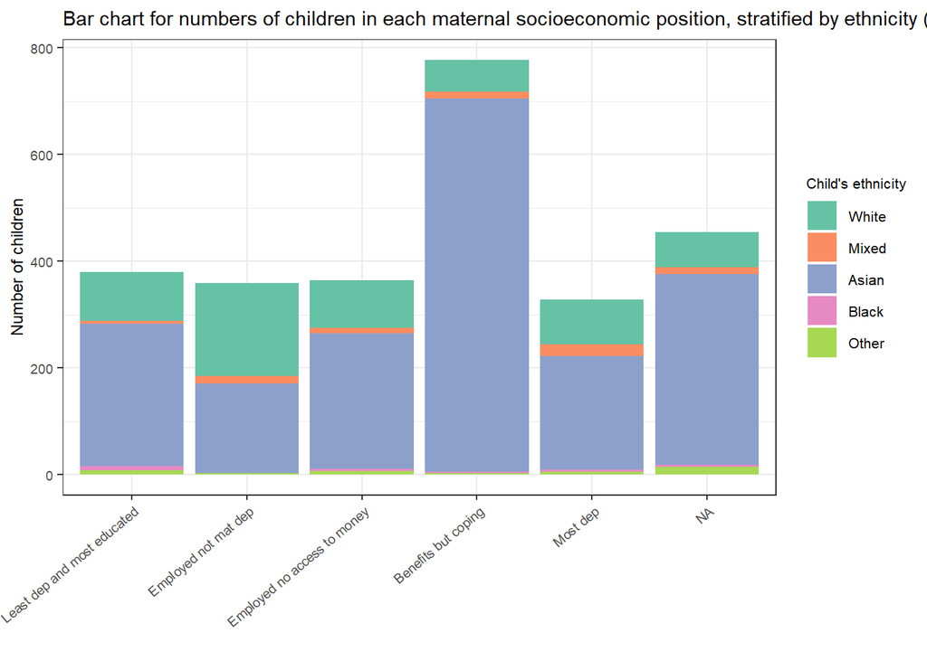

```r
# SEP
df2662_complcase %>%
    ggplot(aes(x = as.factor(mbqlcasep5gp_T0), fill = mbqlcasep5gp_T0)) + geom_bar(aes(fill = factor(ethnicity5_C_T1))) +
    scale_fill_brewer(palette = "Set2") + theme(plot.title = element_text(size = 8),
    axis.text.x = element_text(angle = 45, vjust = 0.6, size = 8), axis.title.y = element_text(size = 8)) +
    labs(title = "Bar chart for numbers of children in each maternal socioeconomic position, stratified by ethnicity (n=2208)",
        x = "", y = "Number of children") + guides(fill = guide_legend(title = "Child's ethnicity",
    theme(legend.title.position = "top", legend.title = element_text(size = 8), legend.text = element_text(size = 8)))) +
    theme_bw() + theme(axis.text.x = element_text(angle = 40, vjust = 1, hjust = 1),
    text = element_text(size = 9))
```

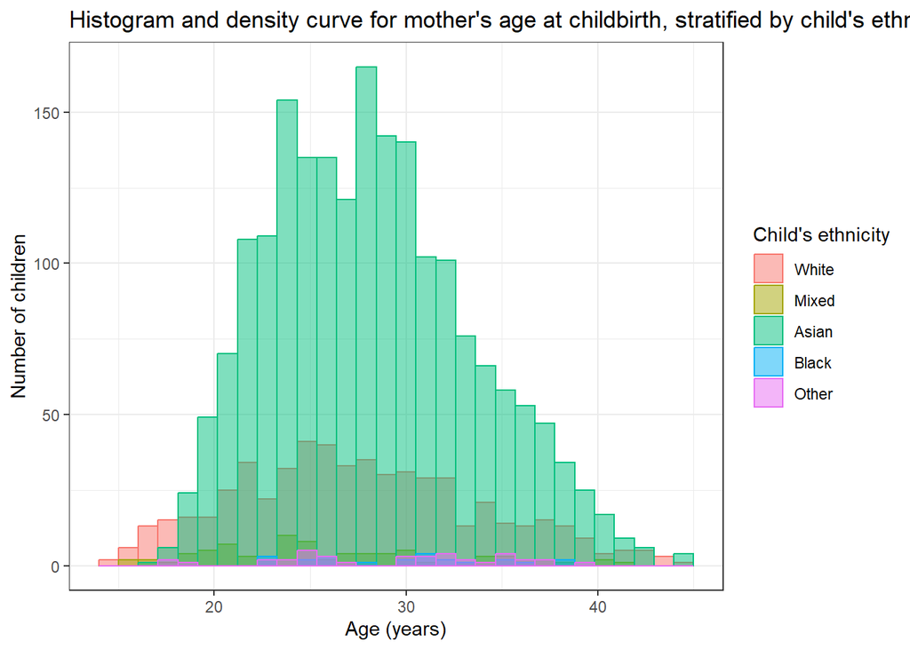

```r
# Mother's age
df2662_complcase %>%
    ggplot(aes(x = admincdobagemy_T0, fill = ethnicity5_C_T1, colour = ethnicity5_C_T1)) +
    geom_histogram(alpha = 0.5, position = "identity", bins = 30) + theme_bw() +
    theme(plot.title = element_text(size = 8), axis.title.x = element_text(size = 8),
        axis.title.y = element_text(size = 8)) + labs(title = "Histogram and density curve for mother's age at childbirth, stratified by child's ethnicity (baseline) (imputed data, n=2662)",
    x = "Age (years)", y = "Number of children") + guides(fill = guide_legend(title = "Child's ethnicity"),
    colour = guide_legend(title = "Child's ethnicity")) + theme_bw()
```

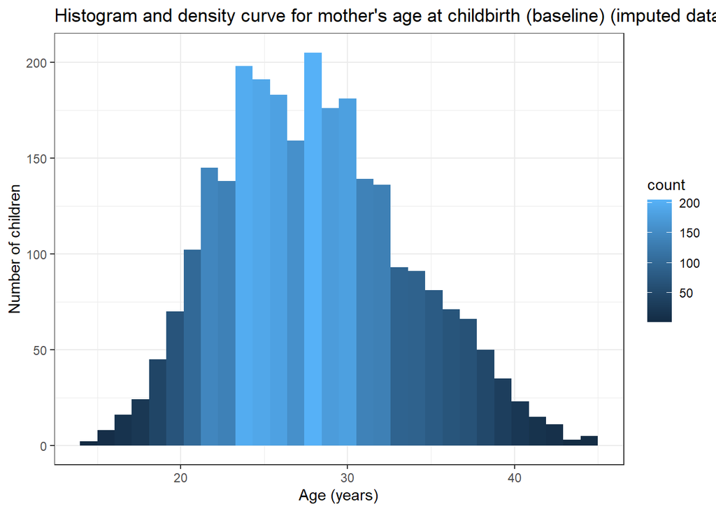

```r
df2662_complcase %>%
    ggplot(aes(x = admincdobagemy_T0)) + geom_histogram(aes(y = after_stat(count),
    fill = after_stat(count)), bins = 30) + theme_bw() + theme(plot.title = element_text(size = 8),
    axis.title.x = element_text(size = 8), axis.title.y = element_text(size = 8)) +
    labs(title = "Histogram and density curve for mother's age at childbirth (baseline) (imputed data, n=2662)",
        x = "Age (years)", y = "Number of children") + theme_bw()
```

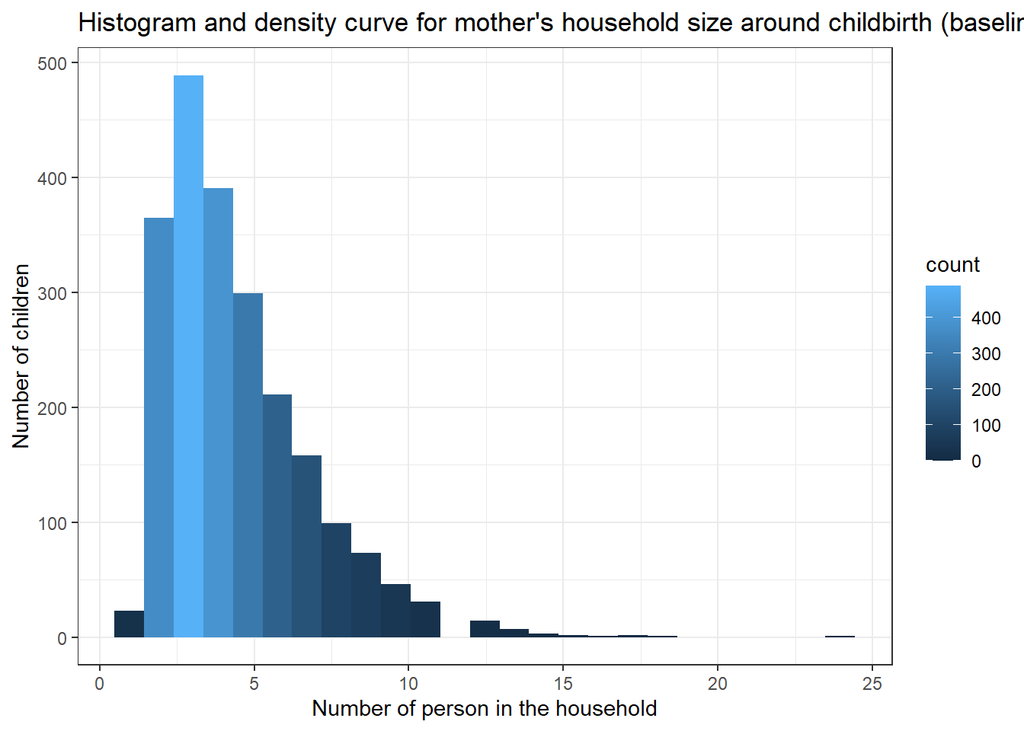

```r
# Household size

df2662_complcase %>%
    ggplot(aes(x = hhd0tothhd_T0)) + geom_histogram(aes(y = after_stat(count), fill = after_stat(count)),
    bins = 25) + theme_bw() + theme(plot.title = element_text(size = 8), axis.title.x = element_text(size = 8),
    axis.title.y = element_text(size = 8)) + labs(title = "Histogram and density curve for mother's household size around childbirth (baseline) (imputed data, n=2662)",
    x = "Number of person in the household", y = "Number of children") + theme_bw()
```

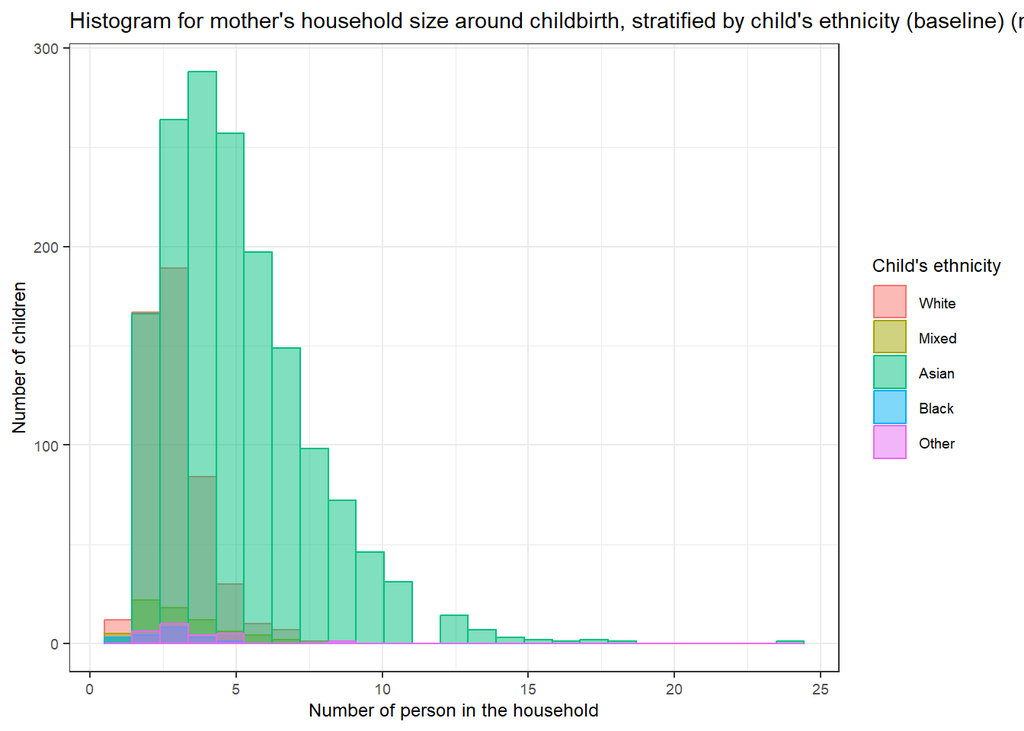

```r
df2662_complcase %>%
    ggplot(aes(x = hhd0tothhd_T0, fill = ethnicity5_C_T1, colour = ethnicity5_C_T1)) +
    geom_histogram(alpha = 0.5, position = "identity", bins = 25) + theme_bw() +
    theme(plot.title = element_text(size = 8), axis.title.x = element_text(size = 8),
        axis.title.y = element_text(size = 8)) + labs(title = "Histogram for mother's household size around childbirth, stratified by child's ethnicity (baseline) (n=2662)",
    x = "Number of person in the household", y = "Number of children") + guides(fill = guide_legend(title = "Child's ethnicity"),
    colour = guide_legend(title = "Child's ethnicity"), legend.text = element_text(size = 8)) +
    theme_bw() + theme(text = element_text(size = 9))
```

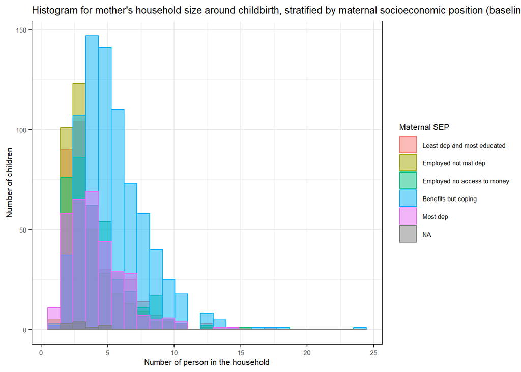

```r
df2662_complcase %>%
    ggplot(aes(x = hhd0tothhd_T0, fill = mbqlcasep5gp_T0, colour = mbqlcasep5gp_T0)) +
    geom_histogram(alpha = 0.5, position = "identity", bins = 25) + theme_bw() +
    theme(plot.title = element_text(size = 8), axis.title.x = element_text(size = 8),
        axis.title.y = element_text(size = 8)) + labs(title = "Histogram for mother's household size around childbirth, stratified by maternal socioeconomic position (baseline) (n=2216)",
    x = "Number of person in the household", y = "Number of children") + guides(fill = guide_legend(title = "Maternal SEP"),
    colour = guide_legend(title = "Maternal SEP"), legend.text = element_text(size = 8)) +
    theme_bw() + theme(text = element_text(size = 8))
```

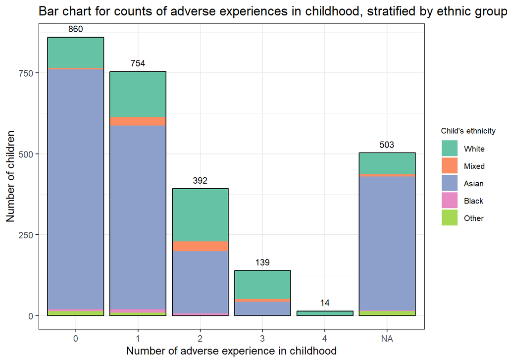

```r
# AE counts
AEcount <- df2662_complcase %>%
    group_by(AE_countT0_T1) %>%
    tally()

df2662_complcase %>%
    ggplot(aes(x = as.factor(AE_countT0_T1), fill = ethnicity5_C_T1)) + geom_bar(aes(fill = factor(ethnicity5_C_T1))) +
    geom_bar(fill = NA, colour = "black") + scale_fill_brewer(palette = "Set2") +
    theme(plot.title = element_text(size = 8), axis.text.x = element_text(vjust = 0.6,
        size = 8), axis.title.y = element_text(size = 8)) + labs(title = "Bar chart for counts of adverse experiences in childhood, stratified by ethnic group (birth-mid-childhood) (n=2662)",
    x = "Number of adverse experience in childhood", y = "Number of children") +
    guides(fill = guide_legend(title = "Child's ethnicity", theme(legend.title.position = "top",
        legend.title = element_text(size = 8), legend.text = element_text(size = 8)))) +
    geom_text(data = AEcount, aes(x = AE_countT0_T1, label = n, y = n, fill = NULL),
        size = 3, vjust = -0.8) + theme_bw()
```

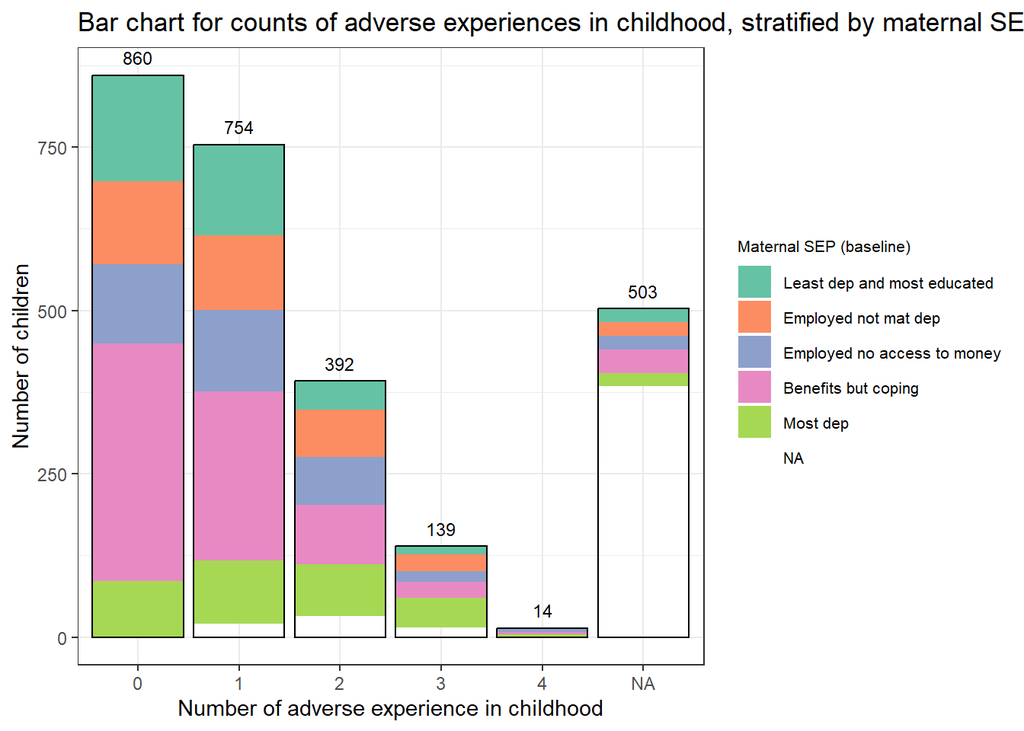

```r
# AE counts

df2662_complcase %>%
    ggplot(aes(x = as.factor(AE_countT0_T1), fill = mbqlcasep5gp_T0)) + geom_bar(aes(fill = factor(mbqlcasep5gp_T0))) +
    geom_bar(fill = NA, colour = "black") + scale_fill_brewer(palette = "Set2") +
    theme(plot.title = element_text(size = 8), axis.text.x = element_text(vjust = 0.6,
        size = 8), axis.title.y = element_text(size = 8)) + labs(title = "Bar chart for counts of adverse experiences in childhood, stratified by maternal SEP (birth-mid-childhood) (n=2662)",
    x = "Number of adverse experience in childhood", y = "Number of children") +
    guides(fill = guide_legend(title = "Maternal SEP (baseline)", theme(legend.title.position = "top",
        legend.title = element_text(size = 8), legend.text = element_text(size = 8)))) +
    geom_text(data = AEcount, aes(x = AE_countT0_T1, label = n, y = n, fill = NULL),
        size = 3, vjust = -0.8) + theme_bw()
```

```r
rm(AEcount)

# Proportion of children in most deprived SEP by ethnicity
dr24 %>%
    group_by(ethnicity5_C_T1) %>%
    count(mbqlcasep5gp_T0) %>%
    mutate(Percentage = scales::percent(n/sum(n))) %>%
    kable()  ## Asian children is lowest proportion of most deprived, highest in Mixed, then Black and Other/White children.
```

| ethnicity5_C_T1 | mbqlcasep5gp_T0 | n | Percentage |
| --- | --- | --- | --- |
| White | Least dep and most educated | 296 | 19.60% |
| White | Employed not mat dep | 457 | 30.26% |
| White | Employed no access to money | 218 | 14.44% |
| White | Benefits but coping | 164 | 10.86% |
| White | Most dep | 179 | 11.85% |
| White | NA | 196 | 12.98% |
| Mixed | Least dep and most educated | 32 | 15.02% |
| Mixed | Employed not mat dep | 42 | 19.72% |
| Mixed | Employed no access to money | 27 | 12.68% |
| Mixed | Benefits but coping | 38 | 17.84% |
| Mixed | Most dep | 41 | 19.25% |
| Mixed | NA | 33 | 15.49% |
| Asian | Least dep and most educated | 519 | 15.3% |
| Asian | Employed not mat dep | 277 | 8.2% |
| Asian | Employed no access to money | 434 | 12.8% |
| Asian | Benefits but coping | 1196 | 35.3% |
| Asian | Most dep | 358 | 10.6% |
| Asian | NA | 604 | 17.8% |
| Black | Least dep and most educated | 16 | 24.6% |
| Black | Employed not mat dep | 6 | 9.2% |
| Black | Employed no access to money | 15 | 23.1% |
| Black | Benefits but coping | 6 | 9.2% |
| Black | Most dep | 11 | 16.9% |
| Black | NA | 11 | 16.9% |
| Other | Least dep and most educated | 21 | 28.4% |
| Other | Employed not mat dep | 4 | 5.4% |
| Other | Employed no access to money | 7 | 9.5% |
| Other | Benefits but coping | 7 | 9.5% |
| Other | Most dep | 9 | 12.2% |
| Other | NA | 26 | 35.1% |
| NA | NA | 3 | 100% |

```r
df2662_complcase %>%
    group_by(ethnicity5_C_T1) %>%
    count(mbqlcasep5gp_T0) %>%
    mutate(Percentage = scales::percent(n/sum(n))) %>%
    kable()  ## Asian children is lowest proportion of most deprived, highest in Mixed, then Black and White children.
```

| ethnicity5_C_T1 | mbqlcasep5gp_T0 | n | Percentage |
| --- | --- | --- | --- |
| White | Least dep and most educated | 92 | 16.28% |
| White | Employed not mat dep | 175 | 30.97% |
| White | Employed no access to money | 89 | 15.75% |
| White | Benefits but coping | 59 | 10.44% |
| White | Most dep | 84 | 14.87% |
| White | NA | 66 | 11.68% |
| Mixed | Least dep and most educated | 6 | 7.6% |
| Mixed | Employed not mat dep | 14 | 17.7% |
| Mixed | Employed no access to money | 11 | 13.9% |
| Mixed | Benefits but coping | 14 | 17.7% |
| Mixed | Most dep | 22 | 27.8% |
| Mixed | NA | 12 | 15.2% |
| Asian | Least dep and most educated | 266 | 13.59% |
| Asian | Employed not mat dep | 167 | 8.53% |
| Asian | Employed no access to money | 254 | 12.98% |
| Asian | Benefits but coping | 699 | 35.72% |
| Asian | Most dep | 213 | 10.88% |
| Asian | NA | 358 | 18.29% |
| Black | Least dep and most educated | 8 | 34.8% |
| Black | Employed not mat dep | 1 | 4.3% |
| Black | Employed no access to money | 4 | 17.4% |
| Black | Benefits but coping | 2 | 8.7% |
| Black | Most dep | 4 | 17.4% |
| Black | NA | 4 | 17.4% |
| Other | Least dep and most educated | 8 | 21.1% |
| Other | Employed not mat dep | 2 | 5.3% |
| Other | Employed no access to money | 6 | 15.8% |
| Other | Benefits but coping | 3 | 7.9% |
| Other | Most dep | 5 | 13.2% |
| Other | NA | 14 | 36.8% |

```r
df2662_complcase %>%
    filter(anyAET0_T1 == "Had AE") %>%
    group_by(ethnicity5_C_T1) %>%
    count(mbqlcasep5gp_T0) %>%
    mutate(Percentage = scales::percent(n/sum(n))) %>%
    kable()  ## Asian children is lowest proportion of most deprived + had AE
```

| ethnicity5_C_T1 | mbqlcasep5gp_T0 | n | Percentage |
| --- | --- | --- | --- |
| White | Least dep and most educated | 64 | 14.35% |
| White | Employed not mat dep | 122 | 27.35% |
| White | Employed no access to money | 75 | 16.82% |
| White | Benefits but coping | 56 | 12.56% |
| White | Most dep | 75 | 16.82% |
| White | NA | 54 | 12.11% |
| Mixed | Least dep and most educated | 6 | 8.5% |
| Mixed | Employed not mat dep | 12 | 16.9% |
| Mixed | Employed no access to money | 10 | 14.1% |
| Mixed | Benefits but coping | 11 | 15.5% |
| Mixed | Most dep | 22 | 31.0% |
| Mixed | NA | 10 | 14.1% |
| Asian | Least dep and most educated | 125 | 12.66% |
| Asian | Employed not mat dep | 88 | 8.92% |
| Asian | Employed no access to money | 144 | 14.59% |
| Asian | Benefits but coping | 327 | 33.13% |
| Asian | Most dep | 133 | 13.48% |
| Asian | NA | 170 | 17.22% |
| Black | Least dep and most educated | 6 | 35.3% |
| Black | Employed not mat dep | 1 | 5.9% |
| Black | Employed no access to money | 3 | 17.6% |
| Black | Most dep | 4 | 23.5% |
| Black | NA | 3 | 17.6% |
| Other | Least dep and most educated | 3 | 21.4% |
| Other | Employed not mat dep | 1 | 7.1% |
| Other | Employed no access to money | 2 | 14.3% |
| Other | Most dep | 3 | 21.4% |
| Other | NA | 5 | 35.7% |

## Table 1 descriptives

```r
# 95%CI of AE prevalence (n=5253) AE=3147
library(glue)
n <- 5253
pY <- round(3147/n, digit = 3)
marginY <- round(qnorm(0.975) * sqrt(pY * (1 - pY)/n), digit = 3)
glue("Had AE proportion (birth to mid-childhood, n=5253) = {pY} ({pY-marginY}, {pY+marginY})")
```

Had AE proportion (birth to mid-childhood, n=5253) = 0.599 (0.586, 0.612)

```r
n <- 5253
pY <- round(2033/n, digit = 3)
marginY <- round(qnorm(0.975) * sqrt(pY * (1 - pY)/n), digit = 3)
glue("Parental mental illness proportion (birth to mid-childhood, n=5253) = {pY} ({pY-marginY}, {pY+marginY})")
```

Parental mental illness proportion (birth to mid-childhood, n=5253) = 0.387 (0.374, 0.4)

```r
n <- 5253
pY <- round(1298/n, digit = 3)
marginY <- round(qnorm(0.975) * sqrt(pY * (1 - pY)/n), digit = 3)
glue("Were bullied proportion (birth to mid-childhood, n=5253) = {pY} ({pY-marginY}, {pY+marginY})")
```

Were bullied proportion (birth to mid-childhood, n=5253) = 0.247 (0.235, 0.259)

```r
n <- 5253
pY <- round(961/n, digit = 3)
marginY <- round(qnorm(0.975) * sqrt(pY * (1 - pY)/n), digit = 3)
glue("Not lived with both parents proportion (mid-childhood, n=5253) = {pY} ({pY-marginY}, {pY+marginY})")
```

Not lived with both parents proportion (mid-childhood, n=5253) = 0.183 (0.173, 0.193)

```r
n <- 5253
pY <- round(536/n, digit = 3)
marginY <- round(qnorm(0.975) * sqrt(pY * (1 - pY)/n), digit = 3)
glue("Not lived with both parents proportion (birth, n=5253) = {pY} ({pY-marginY}, {pY+marginY})")
```

Not lived with both parents proportion (birth, n=5253) = 0.102 (0.094, 0.11)

```r
n <- 5253
pY <- round(380/n, digit = 3)
marginY <- round(qnorm(0.975) * sqrt(pY * (1 - pY)/n), digit = 3)
glue("Paerntal substance use proportion (birth to mid-childhood, n=5253) = {pY} ({pY-marginY}, {pY+marginY})")
```

Paerntal substance use proportion (birth to mid-childhood, n=5253) = 0.072 (0.065, 0.079)

```r
# 95%CI of AE T0-T2 prevalence (n=2662) AE=1747
n <- 2662
pY <- round(1747/n, digit = 3)
marginY <- round(qnorm(0.975) * sqrt(pY * (1 - pY)/n), digit = 3)
glue("Had AE proportion (birth to adolescence, n=2662) = {pY} ({pY-marginY}, {pY+marginY})")
```

Had AE proportion (birth to adolescence, n=2662) = 0.656 (0.638, 0.674)

```r
n <- 2662
pY <- round(1001/n, digit = 3)
marginY <- round(qnorm(0.975) * sqrt(pY * (1 - pY)/n), digit = 3)
glue("Parental mental illness (birth to adolescence, n=2662) = {pY} ({pY-marginY}, {pY+marginY})")
```

Parental mental illness (birth to adolescence, n=2662) = 0.376 (0.358, 0.394)

```r
n <- 2662
pY <- round(919/n, digit = 3)
marginY <- round(qnorm(0.975) * sqrt(pY * (1 - pY)/n), digit = 3)
glue("Were bullied proportion (birth to adolescence, n=2662) = {pY} ({pY-marginY}, {pY+marginY})")
```

Were bullied proportion (birth to adolescence, n=2662) = 0.345 (0.327, 0.363)

```r
n <- 2662
pY <- round(681/n, digit = 3)
marginY <- round(qnorm(0.975) * sqrt(pY * (1 - pY)/n), digit = 3)
glue("Not lived with both parents proportion (adolescence, n=2662) = {pY} ({pY-marginY}, {pY+marginY})")
```

Not lived with both parents proportion (adolescence, n=2662) = 0.256 (0.239, 0.273)

```r
n <- 2662
pY <- round(156/n, digit = 3)
marginY <- round(qnorm(0.975) * sqrt(pY * (1 - pY)/n), digit = 3)
glue("Parental substance use proportion (birth to adolescence, n=2662) = {pY} ({pY-marginY}, {pY+marginY})")
```

Parental substance use proportion (birth to adolescence, n=2662) = 0.059 (0.05, 0.068)

```r
# 95%CI of AE T0-T1 prevalence (n=2662) AE=1535
n <- 2662
pY <- round(1535/n, digit = 3)
marginY <- round(qnorm(0.975) * sqrt(pY * (1 - pY)/n), digit = 3)
glue("Had AE proportion (birth to mid-childhood, n=2662) = {pY} ({pY-marginY}, {pY+marginY})")
```

Had AE proportion (birth to mid-childhood, n=2662) = 0.577 (0.558, 0.596)

```r
n <- 2662
pY <- round(642/n, digit = 3)
marginY <- round(qnorm(0.975) * sqrt(pY * (1 - pY)/n), digit = 3)
glue("Were bullied proportion (birth to mid-childhood, n=2662) = {pY} ({pY-marginY}, {pY+marginY})")
```

Were bullied proportion (birth to mid-childhood, n=2662) = 0.241 (0.225, 0.257)

```r
n <- 2662
pY <- round(154/n, digit = 3)
marginY <- round(qnorm(0.975) * sqrt(pY * (1 - pY)/n), digit = 3)
glue("Parental substance use proportion (mid-childhood, n=2662) = {pY} ({pY-marginY}, {pY+marginY})")
```

Parental substance use proportion (mid-childhood, n=2662) = 0.058 (0.049, 0.067)

```r
n <- 2662
pY <- round(979/n, digit = 3)
marginY <- round(qnorm(0.975) * sqrt(pY * (1 - pY)/n), digit = 3)
glue("Parental mental illness (birth to mid-childhood, n=2662) = {pY} ({pY-marginY}, {pY+marginY})")
```

Parental mental illness (birth to mid-childhood, n=2662) = 0.368 (0.35, 0.386)

```r
n <- 2662
pY <- round(244/n, digit = 3)
marginY <- round(qnorm(0.975) * sqrt(pY * (1 - pY)/n), digit = 3)
glue("Not lived with both parents proportion (around birth, n=2662) = {pY} ({pY-marginY}, {pY+marginY})")
```

Not lived with both parents proportion (around birth, n=2662) = 0.092 (0.081, 0.103)

```r
n <- 2662
pY <- round(421/n, digit = 3)
marginY <- round(qnorm(0.975) * sqrt(pY * (1 - pY)/n), digit = 3)
glue("Not lived with both parents proportion (mid-childhood, n=2662) = {pY} ({pY-marginY}, {pY+marginY})")
```

Not lived with both parents proportion (mid-childhood, n=2662) = 0.158 (0.144, 0.172)

```r
n <- 2662
pY <- round(537/n, digit = 3)
marginY <- round(qnorm(0.975) * sqrt(pY * (1 - pY)/n), digit = 3)
glue("Not lived with both parents proportion (around birth to mid-childhood, n=2662) = {pY} ({pY-marginY}, {pY+marginY})")
```

Not lived with both parents proportion (around birth to mid-childhood, n=2662) = 0.202 (0.187, 0.217)

```r
# base_m_survey.MFC n=11474, BiBChildID=11474, BiBMotherID=10442, BiBFatherID=3045
# Add an indicator of the 5253 GUp children
bibc_vs_5253gu <- left_join(child_info, ID.GU.adult_2surveys.bib.gu1, by = join_by(BiBChildID)) %>% # to get admincdobagefy and admincdobagemy
  left_join(., person_info_C, by = join_by(BiBChildID)) %>% # to get ethnicity_C, YearOfBirth, has_conganom_gp
  left_join(., base_m_survey.MFC, by = join_by(BiBChildID)) %>% ## Obs/BiBChildID=13858, BiBMotherID.y=10443, BiBMotherID.x=4652, BiBFatherID.x=1399, BiBFatherID.y=3046
  select(BiBChildID, Gender = Gender.y, ethnicity5_C = ethnicity5_C.x, ethnicity16_C = ethnicity16_C.x, YearOfBirth = YearOfBirth.x, is_5253, everything(), -ParticipantType.x, -BiBMotherID.x, -BiBFatherID.x, -BiBPersonID.x, -Gender.x, -BiBPregNumber.x, -PregnancyID.x, -BiBPersonID.x.x, -ethsource_C.x, -PersonID.x, -BiBPersonID.y, YearOfBirth.y, -ParticipantType.y, -BiBPersonID.y, -Gender.x, -BiBFatherID.y, -BiBMotherID.y, -BiBPregNumber.y, -PregnancyID.y, -BiBPersonID.y.y, -PersonID.y, -ethnicity16_C.y, -ethnicity5_C.y, -ethsource_C.y, -YearOfBirth.y, -Gender, -admincgender) %>%
  dplyr::mutate(is_5253 = replace_na(is_5253, "No")) %>% ## is_5253=5253, obs=13858
  left_join(., dr24, by = join_by(BiBChildID)) %>%
  select(BiBChildID, is_5253 = is_5253.x, everything(), -BiBPersonID_MorD.x, -BiBMotherID.x, -BiBFatherID.x, -BiBPregNumber.x, -PregnancyID.x, -BiBMotherID.y, -BiBFatherID.y, -is_5253.y, -BiBPersonID_MorD.y, -BiBPregNumber.y, -PregnancyID.y) %>%
  left_join(., ID.df2662, by = join_by(BiBChildID)) %>%
  select(BiBChildID, is_5253, is_aowdr24, anyAET0_T1 = anyAET0_T1.x, anyNotlivewithMFT0_T1 = anyNotlivewithMFT0_T1.x, anyMIT0_T1 = anyMIT0_T1.x, GU_bullied_T1 = GU_bullied_T1.x, school_id_T2 = school_id_T2.x, aow_person_id = aow_person_id.x, everything(), -anyAET0_T1.y, -anyNotlivewithMFT0_T1.y, -anyMIT0_T1.y, -GU_bullied_T1.y, -school_id_T2.y, -aow_person_id.y, -PersonID, -admincdobagefy_T0, -admincdobagemy_T0, -BiBMotherID, -BiBFatherID) %>%
  dplyr::mutate(is_aowdr24 = replace_na(is_aowdr24, "No")) %>%
  mutate(is_bibc = "Yes") %>%
  mutate_at(c("imd_2010_quintile_nat", "YearOfBirth"), as.factor) %>%
  mutate(UK_born_mother = if_else(
    c(org0mumbct %in% "England"| org0mumbct %in% "Northern Ireland"|org0mumbct %in% "Scotland"|org0mumbct %in% "Wales"|org0mumbct %in% "Isle of Man"), "Yes", "No")) %>%
  set_variable_labels(UK_born_mother = "Mother born in the UK",
                      imd_2010_quintile_nat = "IMD for address at BiB recruitment (2010 score)") %>%
  relocate(UK_born_mother, .after=org0mumbct) ## UK_born_mother=7260 (but including 3 NAs)

set.seed(8181)
bibcvsgu <- tableby(is_5253 ~ includeNA(ethnicity5_C) + Gender + includeNA(imd_2010_quintile_nat) + includeNA(mbqlcasep5gp) + hhd0tothhd + includeNA(UK_born_mother) + admincdobagefy + admincdobagemy + includeNA(YearOfBirth) + has_conganom_gp, simulate.p.value=TRUE, B=5000, data = bibc_vs_5253gu, control = tableby.control)
summary(bibcvsgu, pfootnote=TRUE, digits=2, digits.p=3, digits.pct=1)
```

|  | No (N=8605) | Yes (N=5253) | Total (N=13858) | p value |
| --- | --- | --- | --- | --- |
| **Ethnicity - 5 categories** |  |  |  | < 0.001<sup>1</sup> |
| White | 3791 (44.1%) | 1509 (28.7%) | 5300 (38.2%) |  |
| Mixed | 524 (6.1%) | 213 (4.1%) | 737 (5.3%) |  |
| Asian | 3861 (44.9%) | 3388 (64.5%) | 7249 (52.3%) |  |
| Black | 205 (2.4%) | 65 (1.2%) | 270 (1.9%) |  |
| Other | 118 (1.4%) | 73 (1.4%) | 191 (1.4%) |  |
| (Missing) | 106 (1.2%) | 5 (0.1%) | 111 (0.8%) |  |
| **Child gender** |  |  |  | 0.892<sup>1</sup> |
| Female | 4156 (48.3%) | 2548 (48.5%) | 6704 (48.4%) |  |
| Male | 4448 (51.7%) | 2705 (51.5%) | 7153 (51.6%) |  |
| Indeterminate | 1 (0.0%) | 0 (0.0%) | 1 (0.0%) |  |
| **IMD for address at BiB recruitment (2010 score)** |  |  |  | < 0.001<sup>1</sup> |
| 1 | 4608 (53.6%) | 3007 (57.2%) | 7615 (55.0%) |  |
| 2 | 1269 (14.7%) | 796 (15.2%) | 2065 (14.9%) |  |
| 3 | 828 (9.6%) | 435 (8.3%) | 1263 (9.1%) |  |
| 4 | 228 (2.6%) | 107 (2.0%) | 335 (2.4%) |  |
| 5 | 138 (1.6%) | 55 (1.0%) | 193 (1.4%) |  |
| (Missing) | 1534 (17.8%) | 853 (16.2%) | 2387 (17.2%) |  |
| **Socio-economic position (5 group LCA)** |  |  |  | < 0.001<sup>1</sup> |
| Least dep and most educated | 1356 (15.8%) | 884 (16.8%) | 2240 (16.2%) |  |
| Employed not mat dep | 1487 (17.3%) | 786 (15.0%) | 2273 (16.4%) |  |
| Employed no access to money | 1034 (12.0%) | 701 (13.3%) | 1735 (12.5%) |  |
| Benefits but coping | 1936 (22.5%) | 1411 (26.9%) | 3347 (24.2%) |  |
| Most dep | 1211 (14.1%) | 598 (11.4%) | 1809 (13.1%) |  |
| (Missing) | 1581 (18.4%) | 873 (16.6%) | 2454 (17.7%) |  |
| **Total number of members in household** |  |  |  | < 0.001<sup>2</sup> |
| N-Miss | 1535 | 857 | 2392 |  |
| Mean (SD) | 3.89 (2.13) | 4.45 (2.41) | 4.11 (2.26) |  |
| Range | 0.00 - 37.00 | 1.00 - 24.00 | 0.00 - 37.00 |  |
| **Mother born in the UK** |  |  |  | < 0.001<sup>1</sup> |
| No | 3768 (43.8%) | 2830 (53.9%) | 6598 (47.6%) |  |
| Yes | 4837 (56.2%) | 2423 (46.1%) | 7260 (52.4%) |  |
| **Father age at child date of birth (years)** |  |  |  | < 0.001<sup>2</sup> |
| N-Miss | 6580 | 3790 | 10370 |  |
| Mean (SD) | 29.88 (6.54) | 31.05 (6.64) | 30.38 (6.60) |  |
| Range | 16.00 - 60.00 | 17.00 - 59.00 | 16.00 - 60.00 |  |
| **Mother age at child date of birth (years)** |  |  |  | < 0.001<sup>2</sup> |
| Mean (SD) | 27.21 (5.65) | 28.09 (5.50) | 27.54 (5.61) |  |
| Range | 15.00 - 49.00 | 15.00 - 45.00 | 15.00 - 49.00 |  |
| **includeNA(YearOfBirth)** |  |  |  |  |
| 2007 | 1396 (16.2%) | 709 (13.5%) | 2105 (15.2%) |  |
| 2008 | 2199 (25.6%) | 1497 (28.5%) | 3696 (26.7%) |  |
| 2009 | 2342 (27.2%) | 1511 (28.8%) | 3853 (27.8%) |  |
| 2010 | 2177 (25.3%) | 1287 (24.5%) | 3464 (25.0%) |  |
| 2011 | 491 (5.7%) | 249 (4.7%) | 740 (5.3%) |  |
| (Missing) | 0 (0.0%) | 0 (0.0%) | 0 (0.0%) |  |
| **has_conganom_gp** |  |  |  | 0.033<sup>1</sup> |
| No | 8177 (95.0%) | 4948 (94.2%) | 13125 (94.7%) |  |
| Yes | 428 (5.0%) | 305 (5.8%) | 733 (5.3%) |  |

1. Pearson’s Chi-squared test with simulated p-value (based on 5000 replicates)
2. Linear Model ANOVA
3. Pearson’s Chi-squared test

```r
set.seed(8181)
guvsaow <- tableby(is_aowdr24 ~ includeNA(ethnicity5_C) + Gender + includeNA(imd_2010_quintile_nat) + includeNA(mbqlcasep5gp) + hhd0tothhd + includeNA(UK_born_mother) + admincdobagefy + admincdobagemy + includeNA(YearOfBirth) + has_conganom_gp, simulate.p.value=TRUE, B=5000, data = bibc_vs_5253gu, control = tableby.control)
summary(guvsaow, pfootnote=TRUE, digits=2, digits.p=3, digits.pct=1)
```

|  | No (N=11196) | Yes (N=2662) | Total (N=13858) | p value |
| --- | --- | --- | --- | --- |
| **Ethnicity - 5 categories** |  |  |  | < 0.001<sup>1</sup> |
| White | 4735 (42.3%) | 565 (21.2%) | 5300 (38.2%) |  |
| Mixed | 658 (5.9%) | 79 (3.0%) | 737 (5.3%) |  |
| Asian | 5292 (47.3%) | 1957 (73.5%) | 7249 (52.3%) |  |
| Black | 247 (2.2%) | 23 (0.9%) | 270 (1.9%) |  |
| Other | 153 (1.4%) | 38 (1.4%) | 191 (1.4%) |  |
| (Missing) | 111 (1.0%) | 0 (0.0%) | 111 (0.8%) |  |
| **Child gender** |  |  |  | < 0.001<sup>1</sup> |
| Female | 5312 (47.4%) | 1392 (52.3%) | 6704 (48.4%) |  |
| Male | 5883 (52.5%) | 1270 (47.7%) | 7153 (51.6%) |  |
| Indeterminate | 1 (0.0%) | 0 (0.0%) | 1 (0.0%) |  |
| **IMD for address at BiB recruitment (2010 score)** |  |  |  | < 0.001<sup>1</sup> |
| 1 | 5991 (53.5%) | 1624 (61.0%) | 7615 (55.0%) |  |
| 2 | 1678 (15.0%) | 387 (14.5%) | 2065 (14.9%) |  |
| 3 | 1093 (9.8%) | 170 (6.4%) | 1263 (9.1%) |  |
| 4 | 308 (2.8%) | 27 (1.0%) | 335 (2.4%) |  |
| 5 | 181 (1.6%) | 12 (0.5%) | 193 (1.4%) |  |
| (Missing) | 1945 (17.4%) | 442 (16.6%) | 2387 (17.2%) |  |
| **Socio-economic position (5 group LCA)** |  |  |  | < 0.001<sup>1</sup> |
| Least dep and most educated | 1860 (16.6%) | 380 (14.3%) | 2240 (16.2%) |  |
| Employed not mat dep | 1914 (17.1%) | 359 (13.5%) | 2273 (16.4%) |  |
| Employed no access to money | 1371 (12.2%) | 364 (13.7%) | 1735 (12.5%) |  |
| Benefits but coping | 2570 (23.0%) | 777 (29.2%) | 3347 (24.2%) |  |
| Most dep | 1481 (13.2%) | 328 (12.3%) | 1809 (13.1%) |  |
| (Missing) | 2000 (17.9%) | 454 (17.1%) | 2454 (17.7%) |  |
| **Total number of members in household** |  |  |  | < 0.001<sup>2</sup> |
| N-Miss | 1946 | 446 | 2392 |  |
| Mean (SD) | 3.98 (2.18) | 4.66 (2.46) | 4.11 (2.26) |  |
| Range | 0.00 - 37.00 | 1.00 - 24.00 | 0.00 - 37.00 |  |
| **Mother born in the UK** |  |  |  | < 0.001<sup>1</sup> |
| No | 5054 (45.1%) | 1544 (58.0%) | 6598 (47.6%) |  |
| Yes | 6142 (54.9%) | 1118 (42.0%) | 7260 (52.4%) |  |
| **Father age at child date of birth (years)** |  |  |  | 0.017<sup>2</sup> |
| N-Miss | 8405 | 1965 | 10370 |  |
| Mean (SD) | 30.24 (6.61) | 30.91 (6.56) | 30.38 (6.60) |  |
| Range | 16.00 - 60.00 | 17.00 - 54.00 | 16.00 - 60.00 |  |
| **Mother age at child date of birth (years)** |  |  |  | < 0.001<sup>2</sup> |
| Mean (SD) | 27.41 (5.66) | 28.08 (5.36) | 27.54 (5.61) |  |
| Range | 15.00 - 49.00 | 15.00 - 45.00 | 15.00 - 49.00 |  |
| **includeNA(YearOfBirth)** |  |  |  |  |
| 2007 | 1875 (16.7%) | 230 (8.6%) | 2105 (15.2%) |  |
| 2008 | 3029 (27.1%) | 667 (25.1%) | 3696 (26.7%) |  |
| 2009 | 2990 (26.7%) | 863 (32.4%) | 3853 (27.8%) |  |
| 2010 | 2680 (23.9%) | 784 (29.5%) | 3464 (25.0%) |  |
| 2011 | 622 (5.6%) | 118 (4.4%) | 740 (5.3%) |  |
| (Missing) | 0 (0.0%) | 0 (0.0%) | 0 (0.0%) |  |
| **has_conganom_gp** |  |  |  | 0.961<sup>1</sup> |
| No | 10603 (94.7%) | 2522 (94.7%) | 13125 (94.7%) |  |
| Yes | 593 (5.3%) | 140 (5.3%) | 733 (5.3%) |  |

1. Pearson’s Chi-squared test with simulated p-value (based on 5000 replicates)
2. Linear Model ANOVA
3. Pearson’s Chi-squared test

```r
# *Create 3 separate tables of characteristics by study, then combine them (to use)*
bib_tab <- createTable(compareGroups(is_bibc ~ Gender + YearOfBirth + has_conganom_gp + ethnicity5_C + imd_2010_quintile_nat + mbqlcasep5gp + hhd0tothhd + UK_born_mother + admincdobagemy + admincdobagefy + anyAET0_T1 + AE_countT0_T1 + anyAET0_T2 + AE_countT0_T2, data = bibc_vs_5253gu, include.miss = TRUE), show.p.overall = FALSE)

gu_tab <- createTable(compareGroups(is_5253 ~ Gender + YearOfBirth + has_conganom_gp + ethnicity5_C + imd_2010_quintile_nat + mbqlcasep5gp + hhd0tothhd + UK_born_mother + admincdobagemy + admincdobagefy + anyAET0_T1 + AE_countT0_T1 + anyAET0_T2 + AE_countT0_T2, data = bibc_vs_5253gu, include.miss = TRUE), show.p.overall = FALSE)

aow_tab <- createTable(compareGroups(is_aowdr24 ~ Gender + YearOfBirth + has_conganom_gp + ethnicity5_C + imd_2010_quintile_nat + mbqlcasep5gp + hhd0tothhd + UK_born_mother + admincdobagemy + admincdobagefy + anyAET0_T1 + AE_countT0_T1 + anyAET0_T2 + AE_countT0_T2, data = bibc_vs_5253gu, include.miss = TRUE), show.p.overall = T)

cbind("ALL"=bib_tab,"Growing Up"=gu_tab,"AoW (2022-24)"=aow_tab)
```

——–Summary descriptives table ———

```
                                                  ALL              Growing Up                     AoW (2022-24)
                                             _____________  _________________________  ____________________________________
                                                  Yes            No          Yes            No           Yes      p.overall
                                                N=13858        N=8605       N=5253        N=11196       N=2662
```

¯¯¯¯¯¯¯¯¯¯¯¯¯¯¯¯¯¯¯¯¯¯¯¯¯¯¯¯¯¯¯¯¯¯¯¯¯¯¯¯¯¯¯¯¯¯¯¯¯¯¯¯¯¯¯¯¯¯¯¯¯¯¯¯¯¯¯¯¯¯¯¯¯¯¯¯¯¯¯¯¯¯¯¯¯¯¯¯¯¯¯¯¯¯¯¯¯¯¯¯¯¯¯¯¯¯¯¯¯¯¯¯¯¯¯¯¯¯¯¯¯¯¯¯¯¯¯ Child gender: <0.001  
Female 6704 (48.4%) 4156 (48.3%) 2548 (48.5%) 5312 (47.4%) 1392 (52.3%)  
Male 7153 (51.6%) 4448 (51.7%) 2705 (51.5%) 5883 (52.5%) 1270 (47.7%)  
Indeterminate 1 (0.01%) 1 (0.01%) 0 (0.00%) 1 (0.01%) 0 (0.00%)  
YearOfBirth: <0.001  
2007 2105 (15.2%) 1396 (16.2%) 709 (13.5%) 1875 (16.7%) 230 (8.64%)  
2008 3696 (26.7%) 2199 (25.6%) 1497 (28.5%) 3029 (27.1%) 667 (25.1%)  
2009 3853 (27.8%) 2342 (27.2%) 1511 (28.8%) 2990 (26.7%) 863 (32.4%)  
2010 3464 (25.0%) 2177 (25.3%) 1287 (24.5%) 2680 (23.9%) 784 (29.5%)  
2011 740 (5.34%) 491 (5.71%) 249 (4.74%) 622 (5.56%) 118 (4.43%)  
has_conganom_gp: 0.977  
No 13125 (94.7%) 8177 (95.0%) 4948 (94.2%) 10603 (94.7%) 2522 (94.7%)  
Yes 733 (5.29%) 428 (4.97%) 305 (5.81%) 593 (5.30%) 140 (5.26%)  
Ethnicity - 5 categories: <0.001  
White 5300 (38.2%) 3791 (44.1%) 1509 (28.7%) 4735 (42.3%) 565 (21.2%)  
Mixed 737 (5.32%) 524 (6.09%) 213 (4.05%) 658 (5.88%) 79 (2.97%)  
Asian 7249 (52.3%) 3861 (44.9%) 3388 (64.5%) 5292 (47.3%) 1957 (73.5%)  
Black 270 (1.95%) 205 (2.38%) 65 (1.24%) 247 (2.21%) 23 (0.86%)  
Other 191 (1.38%) 118 (1.37%) 73 (1.39%) 153 (1.37%) 38 (1.43%)  
‘Missing’ 111 (0.80%) 106 (1.23%) 5 (0.10%) 111 (0.99%) 0 (0.00%)  
IMD for address at BiB recruitment (2010 score): <0.001  
1 7615 (55.0%) 4608 (53.6%) 3007 (57.2%) 5991 (53.5%) 1624 (61.0%)  
2 2065 (14.9%) 1269 (14.7%) 796 (15.2%) 1678 (15.0%) 387 (14.5%)  
3 1263 (9.11%) 828 (9.62%) 435 (8.28%) 1093 (9.76%) 170 (6.39%)  
4 335 (2.42%) 228 (2.65%) 107 (2.04%) 308 (2.75%) 27 (1.01%)  
5 193 (1.39%) 138 (1.60%) 55 (1.05%) 181 (1.62%) 12 (0.45%)  
‘Missing’ 2387 (17.2%) 1534 (17.8%) 853 (16.2%) 1945 (17.4%) 442 (16.6%)  
Socio-economic position (5 group LCA): <0.001  
Least dep and most educated 2240 (16.2%) 1356 (15.8%) 884 (16.8%) 1860 (16.6%) 380 (14.3%)  
Employed not mat dep 2273 (16.4%) 1487 (17.3%) 786 (15.0%) 1914 (17.1%) 359 (13.5%)  
Employed no access to money 1735 (12.5%) 1034 (12.0%) 701 (13.3%) 1371 (12.2%) 364 (13.7%)  
Benefits but coping 3347 (24.2%) 1936 (22.5%) 1411 (26.9%) 2570 (23.0%) 777 (29.2%)  
Most dep 1809 (13.1%) 1211 (14.1%) 598 (11.4%) 1481 (13.2%) 328 (12.3%)  
‘Missing’ 2454 (17.7%) 1581 (18.4%) 873 (16.6%) 2000 (17.9%) 454 (17.1%)  
Total number of members in household 4.11 (2.26) 3.89 (2.13) 4.45 (2.41) 3.98 (2.18) 4.66 (2.46) <0.001  
Mother born in the UK: <0.001  
No 6598 (47.6%) 3768 (43.8%) 2830 (53.9%) 5054 (45.1%) 1544 (58.0%)  
Yes 7260 (52.4%) 4837 (56.2%) 2423 (46.1%) 6142 (54.9%) 1118 (42.0%)  
Mother age at child date of birth (years) 27.5 (5.61) 27.2 (5.65) 28.1 (5.50) 27.4 (5.66) 28.1 (5.36) <0.001  
Father age at child date of birth (years) 30.4 (6.60) 29.9 (6.54) 31.1 (6.64) 30.2 (6.61) 30.9 (6.56) 0.017  
anyAET0_T1: 0.000  
Had AE 3147 (22.7%) 0 (0.00%) 3147 (59.9%) 1612 (14.4%) 1535 (57.7%)  
No AE 1586 (11.4%) 0 (0.00%) 1586 (30.2%) 726 (6.48%) 860 (32.3%)  
‘Missing’ 9125 (65.8%) 8605 (100%) 520 (9.90%) 8858 (79.1%) 267 (10.0%)  
AE_countT0_T1: 0.000  
0 1586 (11.4%) 0 (0.00%) 1586 (30.2%) 726 (6.48%) 860 (32.3%)  
1 1490 (10.8%) 0 (0.00%) 1490 (28.4%) 736 (6.57%) 754 (28.3%)  
2 827 (5.97%) 0 (0.00%) 827 (15.7%) 435 (3.89%) 392 (14.7%)  
3 340 (2.45%) 0 (0.00%) 340 (6.47%) 201 (1.80%) 139 (5.22%)  
4 44 (0.32%) 0 (0.00%) 44 (0.84%) 30 (0.27%) 14 (0.53%)  
‘Missing’ 9571 (69.1%) 8605 (100%) 966 (18.4%) 9068 (81.0%) 503 (18.9%)  
anyAET0_T2: 0.000  
Had AE 3371 (24.3%) 0 (0.00%) 3371 (64.2%) 1624 (14.5%) 1747 (65.6%)  
No AE 308 (2.22%) 0 (0.00%) 308 (5.86%) 0 (0.00%) 308 (11.6%)  
‘Missing’ 10179 (73.5%) 8605 (100%) 1574 (30.0%) 9572 (85.5%) 607 (22.8%)  
AE_countT0_T2: 0.000  
0 308 (2.22%) 0 (0.00%) 308 (5.86%) 0 (0.00%) 308 (11.6%)  
1 454 (3.28%) 0 (0.00%) 454 (8.64%) 0 (0.00%) 454 (17.1%)  
2 399 (2.88%) 0 (0.00%) 399 (7.60%) 65 (0.58%) 334 (12.5%)  
3 303 (2.19%) 0 (0.00%) 303 (5.77%) 143 (1.28%) 160 (6.01%)  
4 58 (0.42%) 0 (0.00%) 58 (1.10%) 30 (0.27%) 28 (1.05%)  
‘Missing’ 12336 (89.0%) 8605 (100%) 3731 (71.0%) 10958 (97.9%) 1378 (51.8%)  
¯¯¯¯¯¯¯¯¯¯¯¯¯¯¯¯¯¯¯¯¯¯¯¯¯¯¯¯¯¯¯¯¯¯¯¯¯¯¯¯¯¯¯¯¯¯¯¯¯¯¯¯¯¯¯¯¯¯¯¯¯¯¯¯¯¯¯¯¯¯¯¯¯¯¯¯¯¯¯¯¯¯¯¯¯¯¯¯¯¯¯¯¯¯¯¯¯¯¯¯¯¯¯¯¯¯¯¯¯¯¯¯¯¯¯¯¯¯¯¯¯¯¯¯¯¯¯

```r
rm(aow_tab)
rm(gu_tab)
rm(bib_tab)
rm(guvsaow)
rm(bibcvsgu)
rm(bibc_vs_5253gu)
```

The combined table compares the characteristics of children and their families recruited to the BiB Growing Up study and AoW study with the original BiB Birth Cohort. This shows that a higher proportion of children who were recruited into AoW in 2022-24 were female, of the lower IMD quintiles, and of Asian ethnicity, but lower proportion of their mothers were born in UK. These could be mainly explained by the locations and students’ characteristics of the schools recruited into AoW in these two school years. However, the proportion of who had experienced any AE are similar between the GUp cohort sample (n=5253) and sample from AoW 2022-24 (n=2662).

Notes: p-value is based on 1) Mann-Whitney U test or t-test depending on whether row-variable is normal distributed or not, 2) chi-squared or Fisher test.

```r
# table to compare GUp and AoW only

gu_vs_aow <- left_join(ID.GU.adult_2surveys.bib.gu1, dr24, by = join_by(BiBChildID)) %>%
    select(BiBChildID, BiBMotherID = BiBMotherID.x, BiBFatherID = BiBFatherID.x,
        everything(), -BiBMotherID.y, -BiBFatherID.y) %>%
    left_join(., ID.df2662, by = join_by(BiBChildID)) %>%
    select(BiBChildID, BiBMotherID = BiBMotherID.x, BiBFatherID = BiBFatherID.x,
        is_aowdr24, anyAET0_T1 = anyAET0_T1.x, anyNotlivewithMFT0_T1 = anyNotlivewithMFT0_T1.x,
        anyMIT0_T1 = anyMIT0_T1.x, GU_bullied_T1 = GU_bullied_T1.x, school_id_T2 = school_id_T2.x,
        aow_person_id = aow_person_id.x, everything(), -BiBMotherID.y, -BiBFatherID.y,
        -anyAET0_T1.y, -anyNotlivewithMFT0_T1.y, -anyMIT0_T1.y, -GU_bullied_T1.y,
        -school_id_T2.y, -aow_person_id.y, -BiBPregNumber.x, -PregnancyID.x, -PersonID,
        -BiBPersonID_MorD.x, -BiBPregNumber.y, -PregnancyID.y, -BiBPersonID_MorD.y,
        -is_5253.y, is_5253 = is_5253.x) %>%
    dplyr::mutate(is_aowdr24 = replace_na(is_aowdr24, "No")) %>%
    mutate(is_bibc = "Yes") %>%
    set_variable_labels(IMD_2010_score_T0 = "IMD for address at BiB recruitment (2010 score)",
        is_5253 = "Children participated in BiB Birth Cohort and GUp studies")

gu_tab2 <- createTable(compareGroups(is_5253 ~ has_conganom_gp_T1_derived + ethnicity5_C_T1 +
    admincgender_T0 + GU_AgeYears_T1_derived + age_survey_y_selfh_T2 + IMD_2010_score_T0 +
    mbqlcasep5gp_T0 + hhd0tothhd_T0 + admincdobagemy_T0 + admincdobagefy_T0 + anyAET0_T1 +
    AE_countT0_T1 + anyAET0_T2 + AE_countT0_T2 + anyNotlivewithMFT0_T1 + anyNotlivewithMFT0_T2 +
    livewithMF_base_T0 + livewithMF_gu_T1 + livewithMF_aow_T2 + GU_bullied_T1 + aow_anybullied_T2 +
    anyMIT0_T1 + anyMIT0_T2 + anyMIrecordT0_T1 + anyMIrecordT0_T2 + anyMentalillness_M_T1 +
    anyMentalillness_F_T1 + anyAlcSubProbT0_T1 + anyAlcSubProbT0_T2 + anyAlcSubrecordT0_T1 +
    anyAlcSubrecordT0_T2 + anyselfrAlcSubProb, data = gu_vs_aow, include.miss = TRUE),
    show.p.overall = FALSE)
gu_tab2
```

——–Summary descriptives table by ‘Children participated in BiB Birth Cohort and GUp studies’———

```
                                                  Yes
                                                 N=5253
```

¯¯¯¯¯¯¯¯¯¯¯¯¯¯¯¯¯¯¯¯¯¯¯¯¯¯¯¯¯¯¯¯¯¯¯¯¯¯¯¯¯¯¯¯¯¯¯¯¯¯¯¯¯¯¯¯¯¯¯¯¯¯ has_conganom_gp_T1_derived:  
No Record 4948 (94.2%) Yes 305 (5.81%)  
ethnicity5_C_T1:  
White 1510 (28.7%) Mixed 213 (4.05%)  
Asian 3388 (64.5%) Black 65 (1.24%)  
Other 74 (1.41%)  
‘Missing’ 3 (0.06%)  
admincgender_T0:  
Male 2705 (51.5%) Female 2548 (48.5%) Age GUp survey taken (calculated) 9.72 (1.14)  
Age self-harm survey take (AoW) 13.8 (0.82)  
IMD for address at BiB recruitment (2010 score) 43.3 (17.2)  
mbqlcasep5gp_T0:  
Least dep and most educated 884 (16.8%)  
Employed not mat dep 786 (15.0%)  
Employed no access to money 701 (13.3%)  
Benefits but coping 1411 (26.9%) Most dep 598 (11.4%)  
‘Missing’ 873 (16.6%)  
Number of people in mother’s household (baseline) 4.45 (2.41)  
Mother age at child date of birth (years) 28.1 (5.50)  
Father age at child date of birth (years) 31.1 (6.64)  
anyAET0_T1:  
Had AE 3147 (59.9%) No AE 1586 (30.2%) ‘Missing’ 520 (9.90%)  
AE_countT0_T1:  
0 1586 (30.2%) 1 1490 (28.4%) 2 827 (15.7%)  
3 340 (6.47%)  
4 44 (0.84%)  
‘Missing’ 966 (18.4%)  
anyAET0_T2:  
Had AE 3371 (64.2%) No AE 308 (5.86%)  
‘Missing’ 1574 (30.0%) AE_countT0_T2:  
0 308 (5.86%)  
1 454 (8.64%)  
2 399 (7.60%)  
3 303 (5.77%)  
4 58 (1.10%)  
‘Missing’ 3731 (71.0%) anyNotlivewithMFT0_T1:  
No 3108 (59.2%) Yes 1203 (22.9%) ‘Missing’ 942 (17.9%)  
anyNotlivewithMFT0_T2:  
No 1055 (20.1%) Yes 1347 (25.6%) ‘Missing’ 2851 (54.3%) livewithMF_base_T0:  
both parents 3857 (73.4%) not both parents 536 (10.2%)  
‘Missing’ 860 (16.4%)  
livewithMF_gu_T1:  
both parents 3955 (75.3%) not both parents 961 (18.3%)  
‘Missing’ 337 (6.42%)  
livewithMF_aow_T2:  
both parents 1487 (28.3%) not both parents 359 (6.83%)  
‘Missing’ 3407 (64.9%) GU_bullied_T1:  
Yes 1298 (24.7%) No 3853 (73.3%) ‘Missing’ 102 (1.94%)  
aow_anybullied_T2:  
Yes 414 (7.88%)  
No 939 (17.9%)  
‘Missing’ 3900 (74.2%) anyMIT0_T1:  
No 3220 (61.3%) Yes 2033 (38.7%) anyMIT0_T2:  
No 3176 (60.5%) Yes 2077 (39.5%) anyMIrecordT0_T1:  
No 3696 (70.4%) Yes 1557 (29.6%) anyMIrecordT0_T2:  
No 3642 (69.3%) Yes 1611 (30.7%) anyMentalillness_M_T1:  
Possibly 1102 (21.0%) PossiblyNot 4099 (78.0%) ‘Missing’ 52 (0.99%)  
anyMentalillness_F_T1:  
Possibly 35 (0.67%)  
PossiblyNot 37 (0.70%)  
‘Missing’ 5181 (98.6%) anyAlcSubProbT0_T1:  
No 4873 (92.8%) Yes 380 (7.23%)  
anyAlcSubProbT0_T2:  
No 4866 (92.6%) Yes 387 (7.37%)  
anyAlcSubrecordT0_T1:  
No 5166 (98.3%) Yes 87 (1.66%)  
anyAlcSubrecordT0_T2:  
No 5159 (98.2%) Yes 94 (1.79%)  
anyselfrAlcSubProb:  
No 4829 (91.9%) Yes 312 (5.94%)  
‘Missing’ 112 (2.13%)  
¯¯¯¯¯¯¯¯¯¯¯¯¯¯¯¯¯¯¯¯¯¯¯¯¯¯¯¯¯¯¯¯¯¯¯¯¯¯¯¯¯¯¯¯¯¯¯¯¯¯¯¯¯¯¯¯¯¯¯¯¯¯

```r
aow_tab2 <- createTable(compareGroups(is_aowdr24 ~ has_conganom_gp_T1_derived + ethnicity5_C_T1 +
    admincgender_T0 + GU_AgeYears_T1_derived + age_survey_y_selfh_T2 + IMD_2010_score_T0 +
    mbqlcasep5gp_T0 + hhd0tothhd_T0 + admincdobagemy_T0 + admincdobagefy_T0 + anyAET0_T1 +
    AE_countT0_T1 + anyAET0_T2 + AE_countT0_T2 + anyNotlivewithMFT0_T1 + anyNotlivewithMFT0_T2 +
    livewithMF_base_T0 + livewithMF_gu_T1 + livewithMF_aow_T2 + GU_bullied_T1 + aow_anybullied_T2 +
    anyMIT0_T1 + anyMIT0_T2 + anyMIrecordT0_T1 + anyMIrecordT0_T2 + anyMentalillness_M_T1 +
    anyMentalillness_F_T1 + anyAlcSubProbT0_T1 + anyAlcSubProbT0_T2 + anyAlcSubrecordT0_T1 +
    anyAlcSubrecordT0_T2 + anyselfrAlcSubProb, data = gu_vs_aow, include.miss = TRUE),
    show.p.overall = T)
aow_tab2
```